# Mutation_Rates_lmm

Sigurgeir Olafsson

11/3/2019

## Burden of somatic mutation in inflammatory bowel disease

This document describes statistical analyses used to test if inflammatory bowel disease (IBD) affects the somatic mutation burden in the colon.

Any questions or comments on the contents of this file should be directed to Sigurgeir Olafsson, so11'@'sanger.ac.uk

Load the following packages and read in the data from Supplementary Table 2.

```r
library(ggplot2)
library(cowplot)
library(nlme)
library(lme4)
library(reshape2)


## Read the data:
########################
test_cohort <- read.table("/Users/so11/phd/somatic_ibd_p1/manuscript/Cell_submission/Re_submission/Supplementary_material/Supplementary_Table2_crypt_metaData.txt", h=T)

test_cohort$colour <- "#A72608"
test_cohort$colour[test_cohort$cohort=="control_data"] <- "#BFD7EA"
test_cohort$colour[test_cohort$cohort=="ibd_cohort" & test_cohort$type=="Never_Inflamed"] <- "#FCA311"


head(subset(test_cohort, cohort=="ibd_cohort"))
```

```
##    crypt_ID patient_ID Sex Age     cohort Disease DiseaseDuration
## 7  P10B1_24  patient10   F  51 ibd_cohort      UC             0.0
## 8  P10B1_25  patient10   F  51 ibd_cohort      UC             0.0
## 9  P10B1_26  patient10   F  51 ibd_cohort      UC             0.0
## 10 P10B2_10  patient10   F  51 ibd_cohort      UC            15.5
## 11 P10B2_11  patient10   F  51 ibd_cohort      UC            15.5
## 12 P10B2_12  patient10   F  51 ibd_cohort      UC            15.5
##    Purine_years Smoking_years biopsy_ID location           type Coverage
## 7             0             0     P10B1     Left Never_Inflamed 15.43273
## 8             0             0     P10B1     Left Never_Inflamed 16.12947
## 9             0             0     P10B1     Left Never_Inflamed 15.98564
## 10            0             0     P10B2     Left       Inflamed 19.95625
## 11            0             0     P10B2     Left       Inflamed 14.47899
## 12            0             0     P10B2     Left       Inflamed 18.34748
##    snvMedianVAF indelMedianVAF  adj_snv adj_indel SV_count RT_counts
```

[output cut: 34 more lines]

```r
head(subset(test_cohort, cohort=="control_data"))
```

```
##       crypt_ID patient_ID Sex Age       cohort  Disease DiseaseDuration
## 1 HLS_1C_30_B5        HLS   F  60 control_data Controls               0
## 2 HLS_1C_30_D5        HLS   F  60 control_data Controls               0
## 3 HLS_1C_30_G5        HLS   F  60 control_data Controls               0
## 4 HLS_1C_30_H5        HLS   F  60 control_data Controls               0
## 5 HLS_2C_30_D6        HLS   F  60 control_data Controls               0
## 6 HLS_2C_30_E6        HLS   F  60 control_data Controls               0
##   Purine_years Smoking_years biopsy_ID location           type Coverage
## 1           NA            45 HLS_Right    Right Never_Inflamed 18.99627
## 2           NA            45 HLS_Right    Right Never_Inflamed 15.91061
## 3           NA            45 HLS_Right    Right Never_Inflamed 18.68376
## 4           NA            45 HLS_Right    Right Never_Inflamed 13.74696
## 5           NA            45 HLS_Right    Right Never_Inflamed 13.02889
## 6           NA            45 HLS_Right    Right Never_Inflamed 14.51741
##   snvMedianVAF indelMedianVAF  adj_snv adj_indel SV_count RT_counts
```

[output cut: 34 more lines]

```r
dim(subset(test_cohort, cohort=="ibd_cohort"))
```

```
## [1] 446  41
```

```r
dim(subset(test_cohort, cohort=="control_data"))
```

```
## [1] 412  41
```

```r
length(unique(subset(test_cohort, cohort=="ibd_cohort")$patient_ID))
```

```
## [1] 46
```

```r
length(unique(subset(test_cohort, cohort=="ibd_cohort" & Disease=="CD")$patient_ID))
```

```
## [1] 18
```

```r
length(unique(subset(test_cohort, cohort=="ibd_cohort" & Disease=="UC")$patient_ID))
```

```
## [1] 28
```

```r
length(unique(subset(test_cohort, cohort=="control_data")$patient_ID))
```

```
## [1] 41
```

## Linear mixed effects model for substitution counts

I will use the lme() function of the nlme package to fit a linear mixed effects model to the data. This will account for non-independence of the observations - as crypts are grouped by biopsies, and biopsies are nested within patients.

The components of the model are:

### Effect of coverage and VAF

As described in the methods section, I corrected the branch lengths of the phylogenetic trees for Coverage and VAF. The code for doing this is available in https://github.com/Solafsson/somaticIBD/tree/master/phylogenics/treemut.R

I want to test if there is some remaining effect of Coverage and VAF.

```r
model_null.lme <- lme(fixed = adj_snv ~ Age + location,
                      random = list(patient_ID = pdSymm(form = ~ cohort - 1), biopsy_ID = pdSymm(form = ~ cohort - 1)),
                      weights = varIdent(form= ~ 1 | cohort),
                      data = test_cohort, method="ML")

model_cov <- lme(fixed = adj_snv ~ Age + location + Coverage,
                      random = list(patient_ID = pdSymm(form = ~ cohort - 1), biopsy_ID = pdSymm(form = ~ cohort - 1)),
                      weights = varIdent(form= ~ 1 | cohort),
                      data = test_cohort, method="ML")

model_vaf <- lme(fixed = adj_snv ~ Age + location + snvMedianVAF,
                      random = list(patient_ID = pdSymm(form = ~ cohort - 1), biopsy_ID = pdSymm(form = ~ cohort - 1)),
                      weights = varIdent(form= ~ 1 | cohort),
                      data = test_cohort, method="ML")

## Next test to see if Coverage and VAF are significant
anova(model_null.lme,model_cov, test=T)$"p-value"[2]
```

```
## [1] 2.796776e-13
```

```r
anova(model_null.lme,model_vaf, test=T)$"p-value"[2]
```

```
## [1] 0.3951945
```

We conclude that despite the correction during the building of the phylogenetic trees, some effect of coverage remains, but there is no effect of VAF. model_cov will be the null model moving forward.

```r
tapply(test_cohort$snvMedianVAF, test_cohort$cohort, median)
```

```
## control_data   ibd_cohort
##       0.4375       0.4444
```

```r
tapply(test_cohort$Coverage, test_cohort$cohort, median)
```

```
## control_data   ibd_cohort
##     16.29665     18.20483
```

```r
summary(model_cov)
```

```
## Linear mixed-effects model fit by maximum likelihood
##  Data: test_cohort
##        AIC      BIC    logLik
##   13099.53 13161.34 -6536.767
##
## Random effects:
##  Formula: ~cohort - 1 | patient_ID
##  Structure: General positive-definite
##                    StdDev   Corr
## cohortcontrol_data 395.1904 chrtc_
## cohortibd_cohort   989.6054 0
##
##  Formula: ~cohort - 1 | biopsy_ID %in% patient_ID
##  Structure: General positive-definite
##                    StdDev    Corr
## cohortcontrol_data  410.6975 chrtc_
## cohortibd_cohort   1019.5119 0
## Residual            324.5182
##
## Variance function:
##  Structure: Different standard deviations per stratum
##  Formula: ~1 | cohort
##  Parameter estimates:
## control_data   ibd_cohort
##     1.000000     1.078508
## Fixed effects: adj_snv ~ Age + location + Coverage
##                        Value Std.Error  DF   t-value p-value
## (Intercept)        -87.40470 309.86345 643 -0.282075  0.7780
## Age                 36.97453   4.89758  85  7.549555  0.0000
## locationRight      224.75553 105.39557 125  2.132495  0.0349
## locationTransverse 286.57134 108.02432 125  2.652841  0.0090
## Coverage            38.50826   5.16136 643  7.460876  0.0000
##  Correlation:
##                    (Intr) Age    lctnRg lctnTr
## Age                -0.909
## locationRight      -0.143 -0.062
## locationTransverse -0.082 -0.108  0.524
## Coverage           -0.295  0.012  0.076  0.036
##
## Standardized Within-Group Residuals:
##         Min          Q1         Med          Q3         Max
## -4.37314446 -0.46565879 -0.01210378  0.43945845  5.17998740
##
## Number of Observations: 858
## Number of Groups:
##                patient_ID biopsy_ID %in% patient_ID
##                        87                       214
```

### Confirm that the model residuals are normally distributed

That the standardized residuals are normally distributed is an assumption of the model. The residuals of the pediatric control subjects are quite small but I think it is safe to move forward regardless since the residuals don’t look like they are correlated with age.

```r
intervals(model_cov, which = "fixed")
```

```
## Approximate 95% confidence intervals
##
##  Fixed effects:
##                         lower      est.     upper
## (Intercept)        -694.09572 -87.40470 519.28632
## Age                  27.26525  36.97453  46.68381
## locationRight        16.77328 224.75553 432.73778
## locationTransverse   73.40165 286.57134 499.74103
## Coverage             28.40268  38.50826  48.61384
## attr(,"label")
## [1] "Fixed effects:"
```

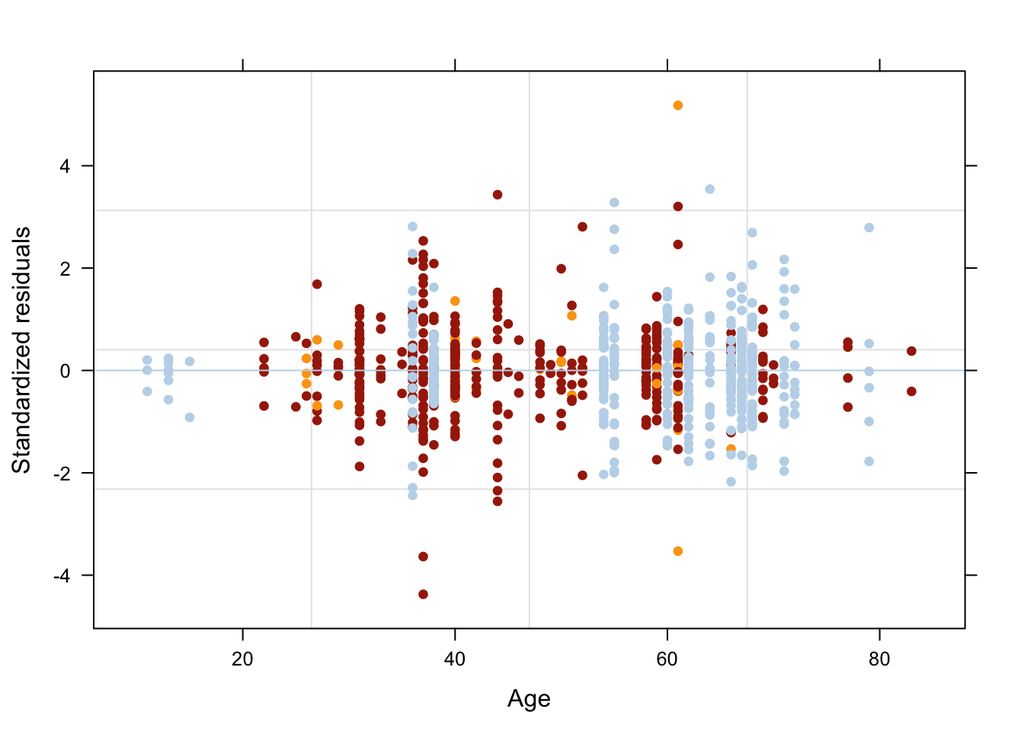

```r
plot(model_cov, resid(., type="p") ~ Age, abline = 0, col=test_cohort$colour, pch=20 )
```

## Including disease duration improves the fit of the linear mixed effects model

Ideally, I would include in the model some measure of inflammation exposure. This could be a function of the disease severity over time. Unfortunately, this data is not available. Some of the patients have decades of IBD history and have in some cases been managed at different hospitals for the duration of their disease. Instead, I will use the time since IBD diagnosis as a proxy for inflammation exposure.

I will fit the same model as model_cov except I add a fixed effect for Disease Duration, that is time since diagnosis plus 6 months. I have added six months to the disease duration since many patients start experiencing symptoms several months before diagnosis, and do avoid assigning a disease duration of 0 to patients that donated biopsies at the time of diagnosis. However, never inflamed regions from IBD patients have Disease duration set to 0.

```r
model_dur_cov.lme <- lme(fixed = adj_snv ~ Age + location +Coverage+ DiseaseDuration,
                      random = list(patient_ID = pdSymm(form = ~ cohort - 1), biopsy_ID = pdSymm(form = ~ cohort - 1)),
                      weights = varIdent(form= ~ 1 | cohort),
                      data = test_cohort, method="ML")
```

This is the model used when reporting on the substitution burden in the main text of the manuscript.

```r
intervals(model_dur_cov.lme, which = "fixed")
```

```
## Approximate 95% confidence intervals
##
##  Fixed effects:
##                          lower       est.     upper
## (Intercept)        -1004.93012 -417.11647 170.69718
## Age                   31.31294   40.55991  49.80689
## locationRight         68.96147  273.86263 478.76380
## locationTransverse   124.49471  335.03364 545.57258
## Coverage              28.05917   38.13617  48.21317
## DiseaseDuration       35.14961   55.08066  75.01170
## attr(,"label")
## [1] "Fixed effects:"
```

```r
summary(model_dur_cov.lme)
```

```
## Linear mixed-effects model fit by maximum likelihood
##  Data: test_cohort
##        AIC     BIC    logLik
##   13075.33 13141.9 -6523.667
##
## Random effects:
##  Formula: ~cohort - 1 | patient_ID
##  Structure: General positive-definite
##                    StdDev   Corr
## cohortcontrol_data 382.9168 chrtc_
## cohortibd_cohort   776.3100 0
##
##  Formula: ~cohort - 1 | biopsy_ID %in% patient_ID
##  Structure: General positive-definite
##                    StdDev   Corr
## cohortcontrol_data 407.3306 chrtc_
## cohortibd_cohort   955.4607 0
## Residual           324.6258
##
## Variance function:
##  Structure: Different standard deviations per stratum
##  Formula: ~1 | cohort
##  Parameter estimates:
## control_data   ibd_cohort
##     1.000000     1.078016
## Fixed effects: adj_snv ~ Age + location + Coverage + DiseaseDuration
##                        Value Std.Error  DF   t-value p-value
## (Intercept)        -417.1165 300.39810 643 -1.388546  0.1655
## Age                  40.5599   4.66712  85  8.690575  0.0000
## locationRight       273.8626 103.88695 124  2.636160  0.0095
## locationTransverse  335.0336 106.74536 124  3.138625  0.0021
## Coverage             38.1362   5.14978 643  7.405396  0.0000
## DiseaseDuration      55.0807  10.10524 124  5.450702  0.0000
##  Correlation:
##                    (Intr) Age    lctnRg lctnTr Coverg
## Age                -0.902
## locationRight      -0.175 -0.037
## locationTransverse -0.115 -0.084  0.525
## Coverage           -0.302  0.013  0.070  0.032
## DiseaseDuration    -0.250  0.172  0.112  0.115 -0.027
##
## Standardized Within-Group Residuals:
##          Min           Q1          Med           Q3          Max
## -4.372904110 -0.473076734 -0.007872753  0.438607354  5.215672522
##
## Number of Observations: 858
## Number of Groups:
##                patient_ID biopsy_ID %in% patient_ID
##                        87                       214
```

```r
anova(model_cov,model_dur_cov.lme, test=T)$"p-value"[2]
```

```
## [1] 3.080897e-07
```

Repeating the above for indels, we see that it is very important to include coverage in the model and that the effect of IBD on the indel burden is relatively large and highly significant.

```r
model_null.indel <- lme(fixed = adj_indel  ~ Age + location + Coverage,
                      random = list(patient_ID = pdSymm(form = ~ cohort - 1), biopsy_ID = pdSymm(form = ~ cohort - 1)),
                      weights = varIdent(form= ~ 1 | cohort),
                      data = test_cohort, method="ML")

model_dur_cov.indel <- lme(fixed = adj_indel ~ Age + location + Coverage + DiseaseDuration,
                      random = list(patient_ID = pdSymm(form = ~ cohort - 1), biopsy_ID = pdSymm(form = ~ cohort - 1)),
                      weights = varIdent(form= ~ 1 | cohort),
                      data = test_cohort, method="ML")

intervals(model_dur_cov.indel, which = "fixed")
```

```
## Approximate 95% confidence intervals
##
##  Fixed effects:
##                           lower       est.      upper
## (Intercept)        -122.4258761 -75.756961 -29.088045
## Age                   0.2871352   1.016070   1.745005
## locationRight       -18.6681225  -7.005482   4.657159
## locationTransverse  -13.8767891  -2.063625   9.749539
## Coverage              6.2859339   7.197521   8.109107
## DiseaseDuration       4.9644615   6.819378   8.674294
## attr(,"label")
## [1] "Fixed effects:"
```

```r
anova(model_null.indel,model_dur_cov.indel, test=T)$"p-value"[2]
```

```
## [1] 5.684663e-11
```

```r
summary(model_dur_cov.indel)
```

```
## Linear mixed-effects model fit by maximum likelihood
##  Data: test_cohort
##        AIC      BIC    logLik
##   9100.206 9166.771 -4536.103
##
## Random effects:
##  Formula: ~cohort - 1 | patient_ID
##  Structure: General positive-definite
##                    StdDev   Corr
## cohortcontrol_data 34.23787 chrtc_
## cohortibd_cohort   80.24012 0
##
##  Formula: ~cohort - 1 | biopsy_ID %in% patient_ID
##  Structure: General positive-definite
##                    StdDev   Corr
## cohortcontrol_data 18.48108 chrtc_
## cohortibd_cohort   81.02364 0
## Residual           24.92330
##
## Variance function:
##  Structure: Different standard deviations per stratum
##  Formula: ~1 | cohort
##  Parameter estimates:
## control_data   ibd_cohort
##     1.000000     2.060215
## Fixed effects: adj_indel ~ Age + location + Coverage + DiseaseDuration
##                        Value Std.Error  DF   t-value p-value
## (Intercept)        -75.75696 23.849826 643 -3.176416  0.0016
## Age                  1.01607  0.367907  85  2.761760  0.0070
## locationRight       -7.00548  5.913076 124 -1.184744  0.2384
## locationTransverse  -2.06362  5.989393 124 -0.344547  0.7310
## Coverage             7.19752  0.465860 643 15.449963  0.0000
## DiseaseDuration      6.81938  0.940461 124  7.251099  0.0000
##  Correlation:
##                    (Intr) Age    lctnRg lctnTr Coverg
## Age                -0.900
## locationRight      -0.142 -0.044
## locationTransverse -0.083 -0.077  0.551
## Coverage           -0.332  0.001  0.134  0.063
## DiseaseDuration    -0.197  0.146  0.069  0.071 -0.027
##
## Standardized Within-Group Residuals:
##          Min           Q1          Med           Q3          Max
## -9.159095168 -0.366578362  0.000915942  0.395838650  3.808574336
##
## Number of Observations: 858
## Number of Groups:
##                patient_ID biopsy_ID %in% patient_ID
##                        87                       214
```

## Restricted analyses

As a sanity check, I want to see how this looks like when I only look at specific restricted sub-types of data. We do observe that never-inflamed regions from IBD patients do not have a higher mutation burden than controls. We also observe that there is an effect of disease duration within the IBD cohort.

```r
never_infl_only <- subset(test_cohort, type=="Never_Inflamed")

model_ibd_never_infl1 <- lme(fixed = adj_snv ~ Age + location + cohort + Coverage,
                      random = list(patient_ID = pdSymm(form = ~ cohort - 1), biopsy_ID = pdSymm(form = ~ cohort - 1)),
                      weights = varIdent(form= ~ 1 | cohort),
                      data = never_infl_only, method="ML")

model_ibd_never_infl2 <- lme(fixed = adj_snv ~ Age + location + Coverage,
                      random = list(patient_ID = pdSymm(form = ~ cohort - 1), biopsy_ID = pdSymm(form = ~ cohort - 1)),
                      weights = varIdent(form= ~ 1 | cohort),
                      data = never_infl_only, method="ML")

anova(model_ibd_never_infl1,model_ibd_never_infl2, test=T)$"p-value"[2]
```

```
## [1] 0.1085639
```

```r
summary(model_ibd_never_infl1)
```

```
## Linear mixed-effects model fit by maximum likelihood
##  Data: never_infl_only
##        AIC      BIC    logLik
##   6887.023 6944.768 -3429.511
##
## Random effects:
##  Formula: ~cohort - 1 | patient_ID
##  Structure: General positive-definite
##                    StdDev   Corr
## cohortcontrol_data 384.3490 chrtc_
## cohortibd_cohort   605.7206 0
##
##  Formula: ~cohort - 1 | biopsy_ID %in% patient_ID
##  Structure: General positive-definite
##                    StdDev     Corr
## cohortcontrol_data 401.956943 chrtc_
## cohortibd_cohort     0.253525 -0.011
## Residual           325.099932
##
## Variance function:
##  Structure: Different standard deviations per stratum
##  Formula: ~1 | cohort
##  Parameter estimates:
## control_data   ibd_cohort
##     1.000000     1.368704
## Fixed effects: adj_snv ~ Age + location + cohort + Coverage
##                        Value Std.Error  DF   t-value p-value
## (Intercept)        -749.5974  347.3841 339 -2.157834  0.0316
## Age                  43.7144    5.2695  50  8.295790  0.0000
## locationRight       345.9150  109.4629  62  3.160112  0.0024
## locationTransverse  392.3270  110.5802  62  3.547895  0.0007
## cohortibd_cohort    375.3420  220.0075  50  1.706042  0.0942
## Coverage             43.3453    6.8905 339  6.290617  0.0000
##  Correlation:
##                    (Intr) Age    lctnRg lctnTr chrtb_
## Age                -0.896
## locationRight      -0.125 -0.087
## locationTransverse -0.102 -0.106  0.598
## cohortibd_cohort   -0.343  0.340 -0.055 -0.072
## Coverage           -0.315 -0.020  0.082  0.077 -0.102
##
## Standardized Within-Group Residuals:
##         Min          Q1         Med          Q3         Max
## -2.61145756 -0.49379516 -0.02026976  0.46136630  4.34392335
##
## Number of Observations: 457
## Number of Groups:
##                patient_ID biopsy_ID %in% patient_ID
##                        53                       117
```

```r
## Just in the diseased samples, is there an effect of disease duration?
ibd_only <- subset(test_cohort, cohort=="ibd_cohort")
model_ibd_only.lme <- lme(fixed = adj_snv ~ Age + location + DiseaseDuration,
                      random = list(patient_ID = pdSymm(form = ~  1), biopsy_ID = pdSymm(form = ~  1)),
                      weights = varIdent(form= ~ 1 ),
                      data = ibd_only, method="ML")

summary(model_ibd_only.lme)
```

```
## Linear mixed-effects model fit by maximum likelihood
##  Data: ibd_only
##        AIC      BIC    logLik
##   6917.104 6949.906 -3450.552
##
## Random effects:
##  Formula: ~1 | patient_ID
##         (Intercept)
## StdDev:    797.3491
##
##  Formula: ~1 | biopsy_ID %in% patient_ID
##         (Intercept) Residual
## StdDev:    937.8262 357.6533
##
## Fixed effects: adj_snv ~ Age + location + DiseaseDuration
##                        Value Std.Error  DF  t-value p-value
## (Intercept)        313.83582  573.1713 336 0.547543  0.5844
## Age                 43.16496   11.7577  44 3.671221  0.0006
## locationRight      297.42913  252.3908  61 1.178447  0.2432
## locationTransverse  42.56386  287.5743  61 0.148010  0.8828
## DiseaseDuration     48.69270   14.1614  61 3.438416  0.0011
##  Correlation:
##                    (Intr) Age    lctnRg lctnTr
## Age                -0.888
## locationRight      -0.343  0.128
## locationTransverse -0.282  0.100  0.389
## DiseaseDuration    -0.086 -0.256  0.173  0.151
##
## Standardized Within-Group Residuals:
##         Min          Q1         Med          Q3         Max
## -4.51759154 -0.39508626 -0.01342805  0.39669836  4.61749499
##
## Number of Observations: 446
## Number of Groups:
##                patient_ID biopsy_ID %in% patient_ID
##                        46                       110
```

```r
## And for indels
model_ibd_only.lme_indel <- lme(fixed = adj_indel ~ Age + location + DiseaseDuration,
                      random = list(patient_ID = pdSymm(form = ~  1), biopsy_ID = pdSymm(form = ~  1)),
                      weights = varIdent(form= ~ 1 ),
                      data = ibd_only, method="ML")

summary(model_ibd_only.lme_indel)
```

```
## Linear mixed-effects model fit by maximum likelihood
##  Data: ibd_only
##        AIC      BIC    logLik
##   5122.958 5155.761 -2553.479
##
## Random effects:
##  Formula: ~1 | patient_ID
##         (Intercept)
## StdDev:    84.69425
##
##  Formula: ~1 | biopsy_ID %in% patient_ID
##         (Intercept) Residual
## StdDev:    79.61041 53.81932
##
## Fixed effects: adj_indel ~ Age + location + DiseaseDuration
##                         Value Std.Error  DF   t-value p-value
## (Intercept)         24.794926  56.50144 336  0.438837  0.6611
## Age                  1.763476   1.16138  44  1.518426  0.1361
## locationRight        7.110892  23.05053  61  0.308491  0.7588
## locationTransverse -24.723128  26.11568  61 -0.946677  0.3475
## DiseaseDuration      6.465650   1.35584  61  4.768753  0.0000
##  Correlation:
##                    (Intr) Age    lctnRg lctnTr
## Age                -0.892
## locationRight      -0.325  0.115
## locationTransverse -0.264  0.087  0.397
## DiseaseDuration    -0.092 -0.242  0.194  0.171
##
## Standardized Within-Group Residuals:
##         Min          Q1         Med          Q3         Max
## -9.02890968 -0.29108453  0.01104675  0.35336272  3.21669774
##
## Number of Observations: 446
## Number of Groups:
##                patient_ID biopsy_ID %in% patient_ID
##                        46                       110
```

In response to a reviewer’s comment, I want to show that the IBD effect on mutation burden is not just driven by crypts carrying driver mutations or the few patients that have really high mutation burdens.

```r
test_cohort_no_driver <- subset(test_cohort, cancer_driver==0)

model_cov_no_driver <- lme(fixed = adj_snv ~ Age + location +Coverage,
                      random = list(patient_ID = pdSymm(form = ~ cohort - 1), biopsy_ID = pdSymm(form = ~ cohort - 1)),
                      weights = varIdent(form= ~ 1 | cohort),
                      data = test_cohort_no_driver, method="ML")

model_dur_cov.lme_no_driver <- lme(fixed = adj_snv ~ Age + location +Coverage+ DiseaseDuration,
                      random = list(patient_ID = pdSymm(form = ~ cohort - 1), biopsy_ID = pdSymm(form = ~ cohort - 1)),
                      weights = varIdent(form= ~ 1 | cohort),
                      data = test_cohort_no_driver, method="ML")

summary(model_dur_cov.lme_no_driver)
```

```
## Linear mixed-effects model fit by maximum likelihood
##  Data: test_cohort_no_driver
##        AIC      BIC    logLik
##   11977.83 12043.27 -5974.913
##
## Random effects:
##  Formula: ~cohort - 1 | patient_ID
##  Structure: General positive-definite
##                    StdDev   Corr
## cohortcontrol_data 392.0365 chrtc_
## cohortibd_cohort   586.3932 0
##
##  Formula: ~cohort - 1 | biopsy_ID %in% patient_ID
##  Structure: General positive-definite
##                    StdDev   Corr
## cohortcontrol_data 407.3221 chrtc_
## cohortibd_cohort   540.0498 0
## Residual           319.1593
##
## Variance function:
##  Structure: Different standard deviations per stratum
##  Formula: ~1 | cohort
##  Parameter estimates:
## control_data   ibd_cohort
##      1.00000      1.09969
## Fixed effects: adj_snv ~ Age + location + Coverage + DiseaseDuration
##                         Value Std.Error  DF   t-value p-value
## (Intercept)        -263.79923 266.92840 585 -0.988277  0.3234
## Age                  38.32713   4.12705  85  9.286807  0.0000
## locationRight       262.72617  93.26097 116  2.817107  0.0057
## locationTransverse  291.17294  97.30724 116  2.992305  0.0034
## Coverage             40.43321   5.26084 585  7.685692  0.0000
## DiseaseDuration      26.87279   7.72819 116  3.477244  0.0007
##  Correlation:
##                    (Intr) Age    lctnRg lctnTr Coverg
## Age                -0.882
## locationRight      -0.196 -0.013
## locationTransverse -0.130 -0.067  0.506
## Coverage           -0.362  0.032  0.057  0.028
## DiseaseDuration    -0.287  0.189  0.118  0.112 -0.027
##
## Standardized Within-Group Residuals:
##         Min          Q1         Med          Q3         Max
## -4.41770396 -0.44815082 -0.02205582  0.42775393  5.34763901
##
## Number of Observations: 792
## Number of Groups:
##                patient_ID biopsy_ID %in% patient_ID
##                        87                       206
```

```r
intervals(model_dur_cov.lme_no_driver, which = "fixed")
```

```
## Approximate 95% confidence intervals
##
##  Fixed effects:
##                         lower       est.     upper
## (Intercept)        -786.06433 -263.79923 258.46586
## Age                  30.15259   38.32713  46.50168
## locationRight        78.71206  262.72617 446.74027
## locationTransverse   99.17511  291.17294 483.17078
## Coverage             30.13999   40.43321  50.72644
## DiseaseDuration      11.62423   26.87279  42.12135
## attr(,"label")
## [1] "Fixed effects:"
```

```r
anova(model_cov_no_driver,model_dur_cov.lme_no_driver, test=T)$"p-value"[2]
```

```
## [1] 0.001361963
```

```r
test_cohort_no_outliers <- test_cohort[!(test_cohort$patient_ID %in% c("patient40", "patient35", "patient36", "patient37", "patient50")),]

model_cov_no_outl <- lme(fixed = adj_snv ~ Age + location +Coverage,
                      random = list(patient_ID = pdSymm(form = ~ cohort - 1), biopsy_ID = pdSymm(form = ~ cohort - 1)),
                      weights = varIdent(form= ~ 1 | cohort),
                      data = test_cohort_no_outliers, method="ML")

model_dur_cov.lme_no_outl <- lme(fixed = adj_snv ~ Age + location +Coverage+ DiseaseDuration,
                      random = list(patient_ID = pdSymm(form = ~ cohort - 1), biopsy_ID = pdSymm(form = ~ cohort - 1)),
                      weights = varIdent(form= ~ 1 | cohort),
                      data = test_cohort_no_outliers, method="ML")

summary(model_dur_cov.lme_no_outl)
```

```
## Linear mixed-effects model fit by maximum likelihood
##  Data: test_cohort_no_outliers
##        AIC      BIC    logLik
##   11342.65 11407.46 -5657.325
##
## Random effects:
##  Formula: ~cohort - 1 | patient_ID
##  Structure: General positive-definite
##                    StdDev   Corr
## cohortcontrol_data 384.7473 chrtc_
## cohortibd_cohort   485.5584 0
##
##  Formula: ~cohort - 1 | biopsy_ID %in% patient_ID
##  Structure: General positive-definite
##                    StdDev   Corr
## cohortcontrol_data 406.3523 chrtc_
## cohortibd_cohort   506.3187 0
## Residual           324.8146
##
## Variance function:
##  Structure: Different standard deviations per stratum
##  Formula: ~1 | cohort
##  Parameter estimates:
## control_data   ibd_cohort
##    1.0000000    0.9058981
## Fixed effects: adj_snv ~ Age + location + Coverage + DiseaseDuration
##                         Value Std.Error  DF   t-value p-value
## (Intercept)        -300.05037 252.91800 561 -1.186354  0.2360
## Age                  38.66071   3.89599  80  9.923215  0.0000
## locationRight       255.53898  90.92362 110  2.810480  0.0059
## locationTransverse  290.39885  95.72779 110  3.033590  0.0030
## Coverage             41.62800   5.05961 561  8.227518  0.0000
## DiseaseDuration      21.41107   7.86482 110  2.722386  0.0075
##  Correlation:
##                    (Intr) Age    lctnRg lctnTr Coverg
## Age                -0.876
## locationRight      -0.225  0.014
## locationTransverse -0.158 -0.042  0.502
## Coverage           -0.369  0.036  0.050  0.026
## DiseaseDuration    -0.298  0.187  0.126  0.129 -0.030
##
## Standardized Within-Group Residuals:
##         Min          Q1         Med          Q3         Max
## -3.03506617 -0.49209352 -0.03293229  0.46172688  4.06270158
##
## Number of Observations: 757
## Number of Groups:
##                patient_ID biopsy_ID %in% patient_ID
##                        82                       195
```

```r
intervals(model_dur_cov.lme_no_outl, which = "fixed")
```

```
## Approximate 95% confidence intervals
##
##  Fixed effects:
##                          lower       est.     upper
## (Intercept)        -794.859650 -300.05037 194.75892
## Age                  30.938234   38.66071  46.38318
## locationRight        76.065225  255.53898 435.01274
## locationTransverse  101.442168  290.39885 479.35554
## Coverage             31.729375   41.62800  51.52662
## DiseaseDuration       5.886741   21.41107  36.93541
## attr(,"label")
## [1] "Fixed effects:"
```

```r
anova(model_cov_no_outl,model_dur_cov.lme_no_outl, test=T)$"p-value"[2]
```

```
## [1] 0.009958068
```

```r
## Repeat that for indels
############################

model_cov_no_driver_id <- lme(fixed = adj_indel ~ Age + location +Coverage,
                      random = list(patient_ID = pdSymm(form = ~ cohort - 1), biopsy_ID = pdSymm(form = ~ cohort - 1)),
                      weights = varIdent(form= ~ 1 | cohort),
                      data = test_cohort_no_driver, method="ML")

model_dur_cov.lme_no_driver_id <- lme(fixed = adj_indel ~ Age + location +Coverage+ DiseaseDuration,
                      random = list(patient_ID = pdSymm(form = ~ cohort - 1), biopsy_ID = pdSymm(form = ~ cohort - 1)),
                      weights = varIdent(form= ~ 1 | cohort),
                      data = test_cohort_no_driver, method="ML")

summary(model_dur_cov.lme_no_driver_id)
```

```
## Linear mixed-effects model fit by maximum likelihood
##  Data: test_cohort_no_driver
##        AIC      BIC    logLik
##   8265.192 8330.636 -4118.596
##
## Random effects:
##  Formula: ~cohort - 1 | patient_ID
##  Structure: General positive-definite
##                    StdDev   Corr
## cohortcontrol_data 34.45967 chrtc_
## cohortibd_cohort   58.48897 0
##
##  Formula: ~cohort - 1 | biopsy_ID %in% patient_ID
##  Structure: General positive-definite
##                    StdDev   Corr
## cohortcontrol_data 18.34481 chrtc_
## cohortibd_cohort   40.76682 0
## Residual           25.01253
##
## Variance function:
##  Structure: Different standard deviations per stratum
##  Formula: ~1 | cohort
##  Parameter estimates:
## control_data   ibd_cohort
##     1.000000     2.012678
## Fixed effects: adj_indel ~ Age + location + Coverage + DiseaseDuration
##                        Value Std.Error  DF   t-value p-value
## (Intercept)        -64.54800 21.891871 585 -2.948492  0.0033
## Age                  0.85393  0.335107  85  2.548216  0.0126
## locationRight       -5.39575  5.629296 116 -0.958512  0.3398
## locationTransverse  -2.77175  5.739703 116 -0.482909  0.6301
## Coverage             7.32241  0.470611 585 15.559365  0.0000
## DiseaseDuration      3.67141  0.702683 116  5.224841  0.0000
##  Correlation:
##                    (Intr) Age    lctnRg lctnTr Coverg
## Age                -0.882
## locationRight      -0.163 -0.026
## locationTransverse -0.099 -0.066  0.541
## Coverage           -0.384  0.020  0.123  0.058
## DiseaseDuration    -0.247  0.179  0.078  0.073 -0.028
##
## Standardized Within-Group Residuals:
##           Min            Q1           Med            Q3           Max
## -9.3030410137 -0.3560553883  0.0009642791  0.4130763750  3.9276427888
##
## Number of Observations: 792
## Number of Groups:
##                patient_ID biopsy_ID %in% patient_ID
##                        87                       206
```

```r
intervals(model_dur_cov.lme_no_driver_id, which = "fixed")
```

```
## Approximate 95% confidence intervals
##
##  Fixed effects:
##                           lower        est.      upper
## (Intercept)        -107.3810626 -64.5480011 -21.714940
## Age                   0.1901714   0.8539262   1.517681
## locationRight       -16.5029615  -5.3957457   5.711470
## locationTransverse  -14.0968156  -2.7717546   8.553306
## Coverage              6.4016263   7.3224119   8.243197
## DiseaseDuration       2.2849374   3.6714082   5.057879
## attr(,"label")
## [1] "Fixed effects:"
```

```r
anova(model_cov_no_driver_id,model_dur_cov.lme_no_driver_id, test=T)$"p-value"[2]
```

```
## [1] 6.840029e-06
```

```r
model_cov_no_outl_id <- lme(fixed = adj_indel ~ Age + location +Coverage,
                      random = list(patient_ID = pdSymm(form = ~ cohort - 1), biopsy_ID = pdSymm(form = ~ cohort - 1)),
                      weights = varIdent(form= ~ 1 | cohort),
                      data = test_cohort_no_outliers, method="ML")

model_dur_cov.lme_no_outl_id <- lme(fixed = adj_indel ~ Age + location +Coverage+ DiseaseDuration,
                      random = list(patient_ID = pdSymm(form = ~ cohort - 1), biopsy_ID = pdSymm(form = ~ cohort - 1)),
                      weights = varIdent(form= ~ 1 | cohort),
                      data = test_cohort_no_outliers, method="ML")

summary(model_dur_cov.lme_no_outl_id)
```

```
## Linear mixed-effects model fit by maximum likelihood
##  Data: test_cohort_no_outliers
##        AIC      BIC   logLik
##   7613.779 7678.591 -3792.89
##
## Random effects:
##  Formula: ~cohort - 1 | patient_ID
##  Structure: General positive-definite
##                    StdDev   Corr
## cohortcontrol_data 34.47266 chrtc_
## cohortibd_cohort   43.96515 0
##
##  Formula: ~cohort - 1 | biopsy_ID %in% patient_ID
##  Structure: General positive-definite
##                    StdDev   Corr
## cohortcontrol_data 18.70581 chrtc_
## cohortibd_cohort   41.83298 0
## Residual           24.91086
##
## Variance function:
##  Structure: Different standard deviations per stratum
##  Formula: ~1 | cohort
##  Parameter estimates:
## control_data   ibd_cohort
##     1.000000     1.290063
## Fixed effects: adj_indel ~ Age + location + Coverage + DiseaseDuration
##                        Value Std.Error  DF   t-value p-value
## (Intercept)        -64.24745 20.334514 561 -3.159527  0.0017
## Age                  0.93831  0.313408  80  2.993879  0.0037
## locationRight       -6.20996  5.565810 110 -1.115733  0.2670
## locationTransverse  -3.21279  5.720085 110 -0.561668  0.5755
## Coverage             7.06202  0.429540 561 16.440870  0.0000
## DiseaseDuration      3.44418  0.675166 110  5.101227  0.0000
##  Correlation:
##                    (Intr) Age    lctnRg lctnTr Coverg
## Age                -0.879
## locationRight      -0.185 -0.006
## locationTransverse -0.121 -0.047  0.536
## Coverage           -0.384  0.028  0.107  0.051
## DiseaseDuration    -0.271  0.182  0.089  0.090 -0.030
##
## Standardized Within-Group Residuals:
##          Min           Q1          Med           Q3          Max
## -4.200782622 -0.411327128  0.004727515  0.494418186  3.044276939
##
## Number of Observations: 757
## Number of Groups:
##                patient_ID biopsy_ID %in% patient_ID
##                        82                       195
```

```r
intervals(model_dur_cov.lme_no_outl_id, which = "fixed")
```

```
## Approximate 95% confidence intervals
##
##  Fixed effects:
##                          lower       est.      upper
## (Intercept)        -104.029939 -64.247454 -24.464970
## Age                   0.317081   0.938307   1.559533
## locationRight       -17.196292  -6.209961   4.776369
## locationTransverse  -14.503639  -3.212787   8.078066
## Coverage              6.221662   7.062016   7.902369
## DiseaseDuration       2.111469   3.444177   4.776884
## attr(,"label")
## [1] "Fixed effects:"
```

```r
anova(model_cov_no_outl_id,model_dur_cov.lme_no_outl_id, test=T)$"p-value"[2]
```

```
## [1] 1.108286e-05
```

Finally, we can assess the effect of smoking in the IBD cohort. Smoking is associated with the risk of colorectal cancer and people have made the rather puzzling observation that smoking increases the risk of CD and is for UC. Unfortunately, smoking status is missing for a few IBD patients and is available for hardly any of the controls.

Looking only in this restricted dataset where smoking information is available, we see that there is a significant fixed effect of smoking years on both the substitution and indel burden.

```r
ibd_smokers <- subset(ibd_only, !is.na(Smoking_years))
ibd_smokers$Disease <- as.factor(as.character(ibd_smokers$Disease))

## Look into the effects of smoking on the mutation burden of IBD patients.
model_ibd_smoking.lme <- lme(fixed = adj_snv ~ Age + location + DiseaseDuration + Coverage + Smoking_years,
                      random = list(patient_ID = pdSymm(form = ~  1), biopsy_ID = pdSymm(form = ~  1)),
                      weights = varIdent(form= ~ 1 ),
                      data = ibd_smokers, method="ML")

model_ibd_only.lme <- lme(fixed = adj_snv ~ Age + location + Coverage + DiseaseDuration,
                      random = list(patient_ID = pdSymm(form = ~  1), biopsy_ID = pdSymm(form = ~  1)),
                      weights = varIdent(form= ~ 1 ),
                      data = ibd_smokers, method="ML")

anova(model_ibd_only.lme,model_ibd_smoking.lme, test=T)$"p-value"[2]
```

```
## [1] 0.00240357
```

```r
intervals(model_ibd_smoking.lme, which = "fixed")
```

```
## Approximate 95% confidence intervals
##
##  Fixed effects:
##                           lower      est.      upper
## (Intercept)        -1375.347433  86.10007 1547.54758
## Age                    1.544197  30.77631   60.00842
## locationRight       -320.807209 342.40334 1005.61389
## locationTransverse  -745.702787 -15.62269  714.45741
## DiseaseDuration       25.670848  57.37138   89.07191
## Coverage              12.236000  29.23763   46.23925
## Smoking_years         17.937511  49.32256   80.70762
## attr(,"label")
## [1] "Fixed effects:"
```

```r
model_ibd_smoking.lme_indel <- lme(fixed = adj_indel ~ Age + location + DiseaseDuration + Coverage + Smoking_years,
                      random = list(patient_ID = pdSymm(form = ~  1), biopsy_ID = pdSymm(form = ~  1)),
                      weights = varIdent(form= ~ 1 ),
                      data = ibd_smokers, method="ML")

model_ibd_only.lme_indel <- lme(fixed = adj_indel ~ Age + location + Coverage + DiseaseDuration,
                      random = list(patient_ID = pdSymm(form = ~  1), biopsy_ID = pdSymm(form = ~  1)),
                      weights = varIdent(form= ~ 1 ),
                      data = ibd_smokers, method="ML")


anova(model_ibd_only.lme_indel,model_ibd_smoking.lme_indel, test=T)$"p-value"[2]
```

```
## [1] 0.0006510436
```

```r
intervals(model_ibd_smoking.lme_indel, which = "fixed")
```

```
## Approximate 95% confidence intervals
##
##  Fixed effects:
##                          lower        est.     upper
## (Intercept)        -226.804673 -85.3093780 56.185917
## Age                  -1.874832   0.8372541  3.549340
## locationRight       -52.633123   5.8187114 64.270546
## locationTransverse -101.615164 -37.2385716 27.138020
## DiseaseDuration       4.550468   7.4654080 10.380348
## Coverage              4.185934   6.7134672  9.241000
## Smoking_years         2.331587   5.2684924  8.205398
## attr(,"label")
## [1] "Fixed effects:"
```

### Smoking in CD patients vs UC

To look for a difference between CD and UC patients, I fit a model which 1) includes a fixed effect for Disease sub-type and 2) a model which includes an interaction term between smoking duration and disease. As show below, neither of these effects is significant, suggesting there is no difference between CD and UC.

```r
model_ibd_smoking.uc_cd <- lme(fixed = adj_snv ~ Age + location + DiseaseDuration + Coverage + Smoking_years + Disease,
                      random = list(patient_ID = pdSymm(form = ~  1), biopsy_ID = pdSymm(form = ~  1)),
                      weights = varIdent(form= ~ 1 ),
                      data = ibd_smokers, method="ML")

anova(model_ibd_smoking.lme,model_ibd_smoking.uc_cd, test=T)$"p-value"[2]
```

```
## [1] 0.5175081
```

```r
summary(model_ibd_smoking.uc_cd)
```

```
## Linear mixed-effects model fit by maximum likelihood
##  Data: ibd_smokers
##        AIC      BIC    logLik
##   5611.219 5653.996 -2794.609
##
## Random effects:
##  Formula: ~1 | patient_ID
##         (Intercept)
## StdDev:    616.1907
##
##  Formula: ~1 | biopsy_ID %in% patient_ID
##         (Intercept) Residual
## StdDev:    1071.162 365.0257
##
## Fixed effects: adj_snv ~ Age + location + DiseaseDuration + Coverage + Smoking_years +      Disease
##                       Value Std.Error  DF   t-value p-value
## (Intercept)        -49.8618  778.4836 277 -0.064050  0.9490
## Age                 29.4953   14.6153  31  2.018118  0.0523
## locationRight      359.9036  333.2673  45  1.079925  0.2859
## locationTransverse  20.3701  369.9271  45  0.055065  0.9563
## DiseaseDuration     60.7308   16.7203  45  3.632153  0.0007
## Coverage            29.3755    8.7360 277  3.362590  0.0009
## Smoking_years       46.2978   16.2456  31  2.849868  0.0077
## DiseaseUC          254.0925  396.5326  31  0.640786  0.5264
##  Correlation:
##                    (Intr) Age    lctnRg lctnTr DssDrt Coverg Smkng_
## Age                -0.779
## locationRight      -0.434  0.213
## locationTransverse -0.353  0.141  0.388
## DiseaseDuration    -0.299 -0.169  0.231  0.189
## Coverage           -0.234  0.024 -0.012  0.008  0.015
## Smoking_years       0.230 -0.344  0.009 -0.075  0.097 -0.020
## DiseaseUC          -0.272 -0.137  0.082  0.152  0.313  0.025 -0.291
##
## Standardized Within-Group Residuals:
##           Min            Q1           Med            Q3           Max
## -4.2478969864 -0.3886124950 -0.0005738139  0.3578250139  4.8747664385
##
## Number of Observations: 361
## Number of Groups:
##                patient_ID biopsy_ID %in% patient_ID
##                        35                        83
```

```r
model_ibd_smoking.uc_cd_interaction <- lme(fixed = adj_snv ~ Age + location + DiseaseDuration + Coverage + Smoking_years*Disease,
                      random = list(patient_ID = pdSymm(form = ~  1), biopsy_ID = pdSymm(form = ~  1)),
                      weights = varIdent(form= ~ 1 ),
                      data = ibd_smokers, method="ML")

anova(model_ibd_smoking.lme,model_ibd_smoking.uc_cd_interaction, test=T)$"p-value"[2]
```

```
## [1] 0.6818694
```

```r
summary(model_ibd_smoking.uc_cd_interaction)
```

```
## Linear mixed-effects model fit by maximum likelihood
##  Data: ibd_smokers
##        AIC      BIC    logLik
##   5612.872 5659.538 -2794.436
##
## Random effects:
##  Formula: ~1 | patient_ID
##         (Intercept)
## StdDev:    602.9758
##
##  Formula: ~1 | biopsy_ID %in% patient_ID
##         (Intercept) Residual
## StdDev:    1073.146 365.0327
##
## Fixed effects: adj_snv ~ Age + location + DiseaseDuration + Coverage + Smoking_years *      Disease
##                            Value Std.Error  DF   t-value p-value
## (Intercept)             160.3853  846.4535 277  0.189479  0.8499
## Age                      27.7459   14.8157  30  1.872732  0.0709
## locationRight           341.0951  334.4162  45  1.019972  0.3132
## locationTransverse      -27.8074  378.1517  45 -0.073535  0.9417
## DiseaseDuration          58.1415   17.1739  45  3.385454  0.0015
## Coverage                 29.2768    8.7505 277  3.345711  0.0009
## Smoking_years           -23.3061  119.7449  30 -0.194631  0.8470
## DiseaseUC               153.0579  428.9863  30  0.356790  0.7237
## Smoking_years:DiseaseUC  71.5173  121.9319  30  0.586535  0.5619
##  Correlation:
##                         (Intr) Age    lctnRg lctnTr DssDrt Coverg Smkng_
## Age                     -0.776
## locationRight           -0.427  0.224
## locationTransverse      -0.400  0.175  0.394
## DiseaseDuration         -0.363 -0.116  0.240  0.228
## Coverage                -0.225  0.028 -0.010  0.012  0.021
## Smoking_years           -0.371  0.143  0.076  0.194  0.257  0.021
## DiseaseUC               -0.388 -0.049  0.104  0.218  0.377  0.033  0.356
## Smoking_years:DiseaseUC  0.403 -0.190 -0.075 -0.206 -0.246 -0.024 -0.991
##                         DissUC
## Age
## locationRight
## locationTransverse
## DiseaseDuration
## Coverage
## Smoking_years
## DiseaseUC
## Smoking_years:DiseaseUC -0.396
##
## Standardized Within-Group Residuals:
##          Min           Q1          Med           Q3          Max
## -4.249024611 -0.387254793  0.004228578  0.358526052  4.872364692
##
## Number of Observations: 361
## Number of Groups:
##                patient_ID biopsy_ID %in% patient_ID
##                        35                        83
```

## IBD affects the between-patient variance in mutation burden

Next I want to see if the between-patient variance is greater in IBD patients than in the controls. This might be expected as disease severity varies between the patients and patients vary in their response to treatment.

```r
model_dur.btwpt.het <- lme(fixed = adj_snv ~ Age + location + Coverage + DiseaseDuration,
                      random = list(patient_ID = pdSymm(form = ~ cohort- 1), biopsy_ID = pdSymm(form = ~ 1)),
                      weights = varIdent(form= ~ 1 | cohort),
                      data = test_cohort, method="ML")

anova(model_dur.btwpt.het, model_dur_cov.lme, test=TRUE)$"p-value"[2]
```

```
## [1] 4.234407e-08
```

```r
model_dur.btwpt.het_indel <- lme(fixed = adj_indel ~ Age + location + Coverage + DiseaseDuration,
                      random = list(patient_ID = pdSymm(form = ~ cohort- 1), biopsy_ID = pdSymm(form = ~ 1)),
                      weights = varIdent(form= ~ 1 | cohort),
                      data = test_cohort, method="ML")

anova(model_dur.btwpt.het_indel, model_dur_cov.indel, test=TRUE)$"p-value"[2]
```

```
## [1] 1.106634e-16
```

I also test if there is a difference in the within-patient variance, as might be expected since different regions of the colon may be differentially affected by the disease. This is ie, a test for heteroscedasticity.

```r
model_dur.btwbio.het <- lme(fixed = adj_snv ~ Age + location + Coverage + DiseaseDuration,
                      random = list(patient_ID = pdSymm(form = ~ 1), biopsy_ID = pdSymm(form = ~cohort-  1)),
                      weights = varIdent(form= ~ 1 | cohort),
                      data = test_cohort, method="ML")

anova(model_dur.btwbio.het, model_dur_cov.lme, test=TRUE)$"p-value"[2]
```

```
## [1] 0.03220335
```

```r
model_dur.btwbio.het_indel <- lme(fixed = adj_indel ~ Age + location + Coverage + DiseaseDuration,
                      random = list(patient_ID = pdSymm(form = ~ 1), biopsy_ID = pdSymm(form = ~cohort-  1)),
                      weights = varIdent(form= ~ 1 | cohort),
                      data = test_cohort, method="ML")

anova(model_dur.btwbio.het_indel, model_dur_cov.indel, test=TRUE)$"p-value"[2]
```

```
## [1] 0.001113461
```

## Predict IBD mutation burden

This is what is shown in Figure 1b.

Both reviewers and co-authors keep insisting that it would be useful to see the ‘residual effect’ from the age model as a function of the disease duration. This is not straightforward in the above lmm framework where I have nested random effects and allow for different variances between cohorts. I’m going to do this a bit differently instead.

I want to train a model on the control data and use it to predict mutation burden in the IBD data. We have to abandon the modeling of different variances in the cohort and predictions can only be made at the cohort level (if Coverage isn’t included, the numbers for crypts from the same patient are identical). There is no way to estimate random effects so

“The predictions at level i are obtained by adding together the contributions from the estimated fixed effects and the estimated random effects at levels less or equal to i and evaluating the model function at the resulting estimated parameters. If group values not included in the original grouping factors are present in newdata, the corresponding predictions will be set to NA for levels greater or equal to the level at which the unknown groups occur.” (From the predict.nlme() documentation)

This obviously means that the model is not exactly the same as the one used to report effects in the main text, but I only use it to graphically convey the message of disease duration being associated with increased mutation burden.

```r
# https://rdrr.io/cran/nlme/man/predict.nlme.html

ctrl <- subset(test_cohort, cohort=="control_data")
ibd <-  subset(test_cohort, cohort=="ibd_cohort" & type!="Never_Inflamed")

model_null.ctrl <- lme(fixed = adj_snv ~ Age + location + Coverage,
                      random = list(patient_ID = pdSymm(form = ~ 1), biopsy_ID = pdSymm(form = ~ 1)),
                      data = ctrl, method="ML")

ibd$predict <- predict(model_null.ctrl,ibd,level=0 )
ibd$delta <- ibd$adj_snv - ibd$predict


## Repeat the above for indels:
##################################


model_null.ctrl_id <- lme(fixed = adj_indel ~ Age + location + Coverage,
                      random = list(patient_ID = pdSymm(form = ~ 1), biopsy_ID = pdSymm(form = ~ 1)),
                      data = ctrl, method="ML")

ibd$predict_id <- predict(model_null.ctrl_id,ibd,level=0 )
ibd$delta_id <- ibd$adj_indel - ibd$predict_id
```

## LMM for signature exposure

I use exactly the same models to test for association between disease duration and exposure to particular mutational signatures, except I use the estimated signature burden as a response variable.

### Signature 1

Signature 1 is a clock-like signature associated with deamination at CpG sites. It is found ubiquitously in the normal colon.

```r
model_null.sbs1 <- lme(fixed = SBS1 ~ Age + location + Coverage,
                      random = list(patient_ID = pdSymm(form = ~ cohort - 1), biopsy_ID = pdSymm(form = ~ cohort - 1)),
                      weights = varIdent(form= ~ 1 | cohort),
                      data = subset(test_cohort, !is.na(SBS1)), method="ML")


model_dur.sbs1 <- lme(fixed = SBS1 ~ Age + location  + Coverage + DiseaseDuration,
                      random = list(patient_ID = pdSymm(form = ~ cohort - 1), biopsy_ID = pdSymm(form = ~ cohort - 1)),
                      weights = varIdent(form= ~ 1 | cohort),
                      data = test_cohort, method="ML")

intervals(model_dur.sbs1, which = "fixed")
```

```
## Approximate 95% confidence intervals
##
##  Fixed effects:
##                          lower       est.      upper
## (Intercept)        -484.531990 -313.53023 -142.52847
## Age                  12.397164   14.98821   17.57926
## locationRight       133.866395  197.25646  260.64653
## locationTransverse  117.029379  183.53252  250.03565
## Coverage              9.921113   13.78684   17.65256
## DiseaseDuration       8.391796   13.16894   17.94609
## attr(,"label")
## [1] "Fixed effects:"
```

```r
anova(model_null.sbs1,model_dur.sbs1, test=T)$"p-value"[2]
```

```
## [1] 2.356767e-07
```

```r
summary(model_dur.sbs1)
```

```
## Linear mixed-effects model fit by maximum likelihood
##  Data: test_cohort
##        AIC      BIC    logLik
##   11367.75 11434.31 -5669.873
##
## Random effects:
##  Formula: ~cohort - 1 | patient_ID
##  Structure: General positive-definite
##                    StdDev   Corr
## cohortcontrol_data 103.5422 chrtc_
## cohortibd_cohort   195.0016 0
##
##  Formula: ~cohort - 1 | biopsy_ID %in% patient_ID
##  Structure: General positive-definite
##                    StdDev   Corr
## cohortcontrol_data 126.5771 chrtc_
## cohortibd_cohort   196.1873 0
## Residual           159.7488
##
## Variance function:
##  Structure: Different standard deviations per stratum
##  Formula: ~1 | cohort
##  Parameter estimates:
## control_data   ibd_cohort
##    1.0000000    0.7595944
## Fixed effects: SBS1 ~ Age + location + Coverage + DiseaseDuration
##                         Value Std.Error  DF   t-value p-value
## (Intercept)        -313.53023  87.38927 643 -3.587743   4e-04
## Age                  14.98821   1.30775  85 11.461083   0e+00
## locationRight       197.25646  32.13940 124  6.137527   0e+00
## locationTransverse  183.53252  33.71776 124  5.443200   0e+00
## Coverage             13.78684   1.97555 643  6.978729   0e+00
## DiseaseDuration      13.16894   2.42206 124  5.437080   0e+00
##  Correlation:
##                    (Intr) Age    lctnRg lctnTr Coverg
## Age                -0.865
## locationRight      -0.210 -0.014
## locationTransverse -0.143 -0.069  0.504
## Coverage           -0.409  0.035  0.053  0.023
## DiseaseDuration    -0.260  0.168  0.161  0.163 -0.037
##
## Standardized Within-Group Residuals:
##         Min          Q1         Med          Q3         Max
## -4.75747511 -0.45563301 -0.01790283  0.42768286  4.94445665
##
## Number of Observations: 858
## Number of Groups:
##                patient_ID biopsy_ID %in% patient_ID
##                        87                       214
```

### Signature 5

Signature 5 is a clock-like signature and likely is caused by various errors and mistakes that occur during replication. It is found ubiquitously in the normal colon.

```r
model_null.sbs5 <- lme(fixed = SBS5 ~ Age + location + Coverage,
                      random = list(patient_ID = pdSymm(form = ~ cohort - 1), biopsy_ID = pdSymm(form = ~ cohort - 1)),
                      weights = varIdent(form= ~ 1 | cohort),
                      data = subset(test_cohort, !is.na(SBS5)), method="ML")

model_dur.sbs5 <- lme(fixed = SBS5 ~ Age + location + Coverage + DiseaseDuration,
                      random = list(patient_ID = pdSymm(form = ~ cohort - 1), biopsy_ID = pdSymm(form = ~ cohort - 1)),
                      weights = varIdent(form= ~ 1 | cohort),
                      data = subset(test_cohort, !is.na(SBS5)), method="ML")


intervals(model_dur.sbs5, which = "fixed")
```

```
## Approximate 95% confidence intervals
##
##  Fixed effects:
##                         lower       est.      upper
## (Intercept)        -640.65320 -427.89572 -215.13825
## Age                  15.91269   19.15854   22.40440
## locationRight       113.31671  196.56859  279.82047
## locationTransverse  128.32979  214.56645  300.80312
## Coverage             13.51224   17.88478   22.25732
## DiseaseDuration      14.83353   22.64205   30.45057
## attr(,"label")
## [1] "Fixed effects:"
```

```r
anova(model_null.sbs5,model_dur.sbs5, test=T)$"p-value"[2]
```

```
## [1] 1.012239e-07
```

```r
summary(model_dur.sbs5)
```

```
## Linear mixed-effects model fit by maximum likelihood
##  Data: subset(test_cohort, !is.na(SBS5))
##        AIC      BIC    logLik
##   11653.63 11720.19 -5812.813
##
## Random effects:
##  Formula: ~cohort - 1 | patient_ID
##  Structure: General positive-definite
##                    StdDev    Corr
## cohortcontrol_data  94.57865 chrtc_
## cohortibd_cohort   322.68507 0
##
##  Formula: ~cohort - 1 | biopsy_ID %in% patient_ID
##  Structure: General positive-definite
##                    StdDev   Corr
## cohortcontrol_data 156.0081 chrtc_
## cohortibd_cohort   363.4798 0
## Residual           176.8126
##
## Variance function:
##  Structure: Different standard deviations per stratum
##  Formula: ~1 | cohort
##  Parameter estimates:
## control_data   ibd_cohort
##     1.000000     0.766771
## Fixed effects: SBS5 ~ Age + location + Coverage + DiseaseDuration
##                        Value Std.Error  DF   t-value p-value
## (Intercept)        -427.8957 108.72823 643 -3.935461   1e-04
## Age                  19.1585   1.63824  85 11.694581   0e+00
## locationRight       196.5686  42.20954 124  4.656970   0e+00
## locationTransverse  214.5665  43.72286 124  4.907421   0e+00
## Coverage             17.8848   2.23455 643  8.003734   0e+00
## DiseaseDuration      22.6421   3.95900 124  5.719134   0e+00
##  Correlation:
##                    (Intr) Age    lctnRg lctnTr Coverg
## Age                -0.883
## locationRight      -0.185 -0.054
## locationTransverse -0.121 -0.105  0.523
## Coverage           -0.357  0.016  0.060  0.024
## DiseaseDuration    -0.221  0.161  0.118  0.123 -0.032
##
## Standardized Within-Group Residuals:
##        Min         Q1        Med         Q3        Max
## -4.4392688 -0.4708778 -0.0204699  0.4532069  4.2271209
##
## Number of Observations: 858
## Number of Groups:
##                patient_ID biopsy_ID %in% patient_ID
##                        87                       214
```

### Signature 18

Signature 18 is associated with reactive oxygen species. It is found ubiquitously in the normal colon.

```r
model_null.sbs18 <- lme(fixed = SBS18 ~ Age + location + Coverage,
                      random = list(patient_ID = pdSymm(form = ~ cohort - 1), biopsy_ID = pdSymm(form = ~ cohort - 1)),
                      weights = varIdent(form= ~ 1 | cohort),
                      data = subset(test_cohort, !is.na(SBS18)), method="ML")

model_dur.sbs18 <- lme(fixed = SBS18 ~ Age + location + Coverage + DiseaseDuration,
                      random = list(patient_ID = pdSymm(form = ~ cohort - 1), biopsy_ID = pdSymm(form = ~ cohort - 1)),
                      weights = varIdent(form= ~ 1 | cohort),
                      data = subset(test_cohort, !is.na(SBS18)), method="ML")

intervals(model_dur.sbs18, which = "fixed")
```

```
## Approximate 95% confidence intervals
##
##  Fixed effects:
##                          lower        est.      upper
## (Intercept)        -230.991462 -115.996894  -1.002326
## Age                   3.818784    5.646845   7.474905
## locationRight        91.121312  123.508853 155.896393
## locationTransverse   64.896058   98.208645 131.521233
## Coverage              4.301672    6.598387   8.895102
## DiseaseDuration       5.763773    8.975114  12.186454
## attr(,"label")
## [1] "Fixed effects:"
```

```r
anova(model_null.sbs18,model_dur.sbs18, test=T)$"p-value"[2]
```

```
## [1] 3.177105e-07
```

```r
summary(model_dur.sbs18)
```

```
## Linear mixed-effects model fit by maximum likelihood
##  Data: subset(test_cohort, !is.na(SBS18))
##        AIC      BIC    logLik
##   10470.88 10537.44 -5221.438
##
## Random effects:
##  Formula: ~cohort - 1 | patient_ID
##  Structure: General positive-definite
##                    StdDev   Corr
## cohortcontrol_data 106.8279 chrtc_
## cohortibd_cohort   121.6484 0
##
##  Formula: ~cohort - 1 | biopsy_ID %in% patient_ID
##  Structure: General positive-definite
##                    StdDev    Corr
## cohortcontrol_data  50.39509 chrtc_
## cohortibd_cohort   140.62500 0
## Residual            84.33972
##
## Variance function:
##  Structure: Different standard deviations per stratum
##  Formula: ~1 | cohort
##  Parameter estimates:
## control_data   ibd_cohort
##    1.0000000    0.9195342
## Fixed effects: SBS18 ~ Age + location + Coverage + DiseaseDuration
##                         Value Std.Error  DF   t-value p-value
## (Intercept)        -115.99689  58.76718 643 -1.973838  0.0488
## Age                   5.64684   0.92266  85  6.120210  0.0000
## locationRight       123.50885  16.42081 124  7.521484  0.0000
## locationTransverse   98.20865  16.88982 124  5.814666  0.0000
## Coverage              6.59839   1.17372 643  5.621771  0.0000
## DiseaseDuration       8.97511   1.62818 124  5.512353  0.0000
##  Correlation:
##                    (Intr) Age    lctnRg lctnTr Coverg
## Age                -0.882
## locationRight      -0.181 -0.009
## locationTransverse -0.120 -0.047  0.535
## Coverage           -0.365  0.027  0.098  0.045
## DiseaseDuration    -0.260  0.149  0.119  0.119 -0.031
##
## Standardized Within-Group Residuals:
##         Min          Q1         Med          Q3         Max
## -3.81443306 -0.40160532 -0.04386662  0.34891054  9.46477667
##
## Number of Observations: 858
## Number of Groups:
##                patient_ID biopsy_ID %in% patient_ID
##                        87                       214
```

## Signature 32

Signature 32 is associated with azathioprine therapy in PCAWG and COSMIC.

It is associated with disease duration, but this is presumably because only patients undergo purine therapy. We are more interested in finding out if this signature associates with the duration of purine therapy but we see that this is not the case (See Figure S5A and B).

```r
model_null.sbs32 <- lme(fixed = SBS32 ~ Age + location + Coverage,
                      random = list(patient_ID = pdSymm(form = ~ cohort - 1), biopsy_ID = pdSymm(form = ~ cohort - 1)),
                      weights = varIdent(form= ~ 1 | cohort),
                      data = test_cohort, method="ML")

model_dur.sbs32 <- lme(fixed = SBS32 ~ Age + location +Coverage+ DiseaseDuration,
                      random = list(patient_ID = pdSymm(form = ~ cohort - 1), biopsy_ID = pdSymm(form = ~ cohort - 1)),
                      weights = varIdent(form= ~ 1 | cohort),
                      data = test_cohort, method="ML")

#summary(model_dur.sbs32)
intervals(model_dur.sbs32, which = "fixed")
```

```
## Approximate 95% confidence intervals
##
##  Fixed effects:
##                            lower        est.     upper
## (Intercept)        -17.620951638  2.64282436 22.906600
## Age                 -0.386370657 -0.08607584  0.214219
## locationRight       -4.539638576 -0.12147116  4.296696
## locationTransverse  -3.952325912  0.56900219  5.090330
## Coverage             0.006041349  0.55747918  1.108917
## DiseaseDuration      2.992463846  5.03424810  7.076032
## attr(,"label")
## [1] "Fixed effects:"
```

```r
anova(model_null.sbs32,model_dur.sbs32, test=T)$"p-value"[2]
```

```
## [1] 2.016493e-05
```

Test for association between SBS32 burden and duration of purine therapy:

```r
purine_users <- subset(test_cohort, cohort=="ibd_cohort" & !is.na(Purine_years))

model_null.sbs32_pur <- lme(fixed = SBS32 ~ Age + location + Coverage,
                      random = list(patient_ID = pdSymm(form = ~ 1), biopsy_ID = pdSymm(form = ~ 1)),
                      weights = varIdent(form= ~ 1),
                      data = purine_users, method="ML")

model_dur.sbs32_pur <- lme(fixed = SBS32 ~ Age + location + Coverage + Purine_years,
                      random = list(patient_ID = pdSymm(form = ~ 1), biopsy_ID = pdSymm(form = ~ 1)),
                      weights = varIdent(form= ~ 1),
                      data = purine_users, method="ML")

#summary(model_dur.sbs32)
intervals(model_dur.sbs32_pur, which = "fixed")
```

```
## Approximate 95% confidence intervals
##
##  Fixed effects:
##                          lower       est.      upper
## (Intercept)        -137.903206 11.7513472 161.405900
## Age                  -2.114517  0.9112276   3.936972
## locationRight       -74.940579 -4.3725403  66.195498
## locationTransverse  -84.894768 -5.7681087  73.358550
## Coverage             -1.435816  0.6391767   2.714169
## Purine_years         -8.714586  0.4925542   9.699694
## attr(,"label")
## [1] "Fixed effects:"
```

```r
anova(model_null.sbs32_pur,model_dur.sbs32_pur, test=T)$"p-value"[2]
```

```
## [1] 0.9139917
```

## ID1 and ID2

The indel signatures ID1 and ID2 are both thought to be the result of polymerase slippage during DNA replication.

```r
model_null.id1 <- lme(fixed = ID1 ~ Age + location + Coverage,
                      random = list(patient_ID = pdSymm(form = ~ cohort - 1), biopsy_ID = pdSymm(form = ~ cohort - 1)),
                      weights = varIdent(form= ~ 1 | cohort),
                      data = subset(test_cohort, !is.na(ID1)), method="ML")

model_dur.id1<- lme(fixed = ID1 ~ Age + location + Coverage + DiseaseDuration,
                      random = list(patient_ID = pdSymm(form = ~ cohort - 1), biopsy_ID = pdSymm(form = ~ cohort - 1)),
                      weights = varIdent(form= ~ 1 | cohort),
                      data = test_cohort, method="ML")

intervals(model_dur.id1, which = "fixed")
```

```
## Approximate 95% confidence intervals
##
##  Fixed effects:
##                          lower        est.      upper
## (Intercept)        -100.493285 -75.2383160 -49.983347
## Age                   0.597831   0.9817971   1.365763
## locationRight         2.014239   9.2812176  16.548196
## locationTransverse    2.194511   9.5902036  16.985896
## Coverage              4.323855   4.9055077   5.487160
## DiseaseDuration       3.254038   4.3405773   5.427117
## attr(,"label")
## [1] "Fixed effects:"
```

```r
anova(model_null.id1,model_dur.id1, test=T)$"p-value"[2]
```

```
## [1] 4.013318e-12
```

```r
summary(model_dur.id1)
```

```
## Linear mixed-effects model fit by maximum likelihood
##  Data: test_cohort
##        AIC      BIC    logLik
##   8263.449 8330.013 -4117.724
##
## Random effects:
##  Formula: ~cohort - 1 | patient_ID
##  Structure: General positive-definite
##                    StdDev   Corr
## cohortcontrol_data 16.19367 chrtc_
## cohortibd_cohort   38.91748 0
##
##  Formula: ~cohort - 1 | biopsy_ID %in% patient_ID
##  Structure: General positive-definite
##                    StdDev   Corr
## cohortcontrol_data 10.71523 chrtc_
## cohortibd_cohort   59.76040 0
## Residual           17.39239
##
## Variance function:
##  Structure: Different standard deviations per stratum
##  Formula: ~1 | cohort
##  Parameter estimates:
## control_data   ibd_cohort
##      1.00000      1.60966
## Fixed effects: ID1 ~ Age + location + Coverage + DiseaseDuration
##                        Value Std.Error  DF   t-value p-value
## (Intercept)        -75.23832 12.906377 643 -5.829546  0.0000
## Age                  0.98180  0.193795  85  5.066172  0.0000
## locationRight        9.28122  3.684431 124  2.519037  0.0130
## locationTransverse   9.59020  3.749691 124  2.557599  0.0117
## Coverage             4.90551  0.297249 643 16.503003  0.0000
## DiseaseDuration      4.34058  0.550886 124  7.879259  0.0000
##  Correlation:
##                    (Intr) Age    lctnRg lctnTr Coverg
## Age                -0.877
## locationRight      -0.152 -0.061
## locationTransverse -0.087 -0.098  0.552
## Coverage           -0.386 -0.001  0.126  0.056
## DiseaseDuration    -0.182  0.147  0.062  0.065 -0.038
##
## Standardized Within-Group Residuals:
##        Min         Q1        Med         Q3        Max
## -6.5489332 -0.4438245  0.0221187  0.4790144  4.8445571
##
## Number of Observations: 858
## Number of Groups:
##                patient_ID biopsy_ID %in% patient_ID
##                        87                       214
```

```r
model_null.id2 <- lme(fixed = ID2 ~ Age + location + Coverage,
                      random = list(patient_ID = pdSymm(form = ~ cohort - 1), biopsy_ID = pdSymm(form = ~ cohort - 1)),
                      weights = varIdent(form= ~ 1 | cohort),
                      data = subset(test_cohort, !is.na(ID2)), method="ML")

model_dur.id2<- lme(fixed = ID2 ~ Age + location + Coverage + DiseaseDuration,
                      random = list(patient_ID = pdSymm(form = ~ cohort - 1), biopsy_ID = pdSymm(form = ~ cohort - 1)),
                      weights = varIdent(form= ~ 1 | cohort),
                      data = test_cohort, method="ML")

intervals(model_dur.id2, which = "fixed")
```

```
## Approximate 95% confidence intervals
##
##  Fixed effects:
##                          lower        est.     upper
## (Intercept)        -8.62915047 -2.89036787 2.8484147
## Age                -0.04086508  0.04857902 0.1380231
## locationRight      -1.31123002  0.63738067 2.5859914
## locationTransverse -0.22206230  1.75070172 3.7234657
## Coverage            0.08277014  0.18303615 0.2833022
## DiseaseDuration     1.14775684  1.73870496 2.3296531
## attr(,"label")
## [1] "Fixed effects:"
```

```r
anova(model_null.id2,model_dur.id2, test=T)$"p-value"[2]
```

```
## [1] 9.450266e-08
```

```r
summary(model_dur.id2)
```

```
## Linear mixed-effects model fit by maximum likelihood
##  Data: test_cohort
##        AIC      BIC    logLik
##   6387.282 6453.846 -3179.641
##
## Random effects:
##  Formula: ~cohort - 1 | patient_ID
##  Structure: General positive-definite
##                    StdDev    Corr
## cohortcontrol_data  2.831285 chrtc_
## cohortibd_cohort   21.307736 0.206
##
##  Formula: ~cohort - 1 | biopsy_ID %in% patient_ID
##  Structure: General positive-definite
##                    StdDev    Corr
## cohortcontrol_data  3.695534 chrtc_
## cohortibd_cohort   33.970514 0.97
## Residual            2.294891
##
## Variance function:
##  Structure: Different standard deviations per stratum
##  Formula: ~1 | cohort
##  Parameter estimates:
## control_data   ibd_cohort
##     1.000000     8.967835
## Fixed effects: ID2 ~ Age + location + Coverage + DiseaseDuration
##                         Value Std.Error  DF   t-value p-value
## (Intercept)        -2.8903679 2.9327651 643 -0.985544  0.3247
## Age                 0.0485790 0.0451441  85  1.076089  0.2849
## locationRight       0.6373807 0.9879652 124  0.645145  0.5200
## locationTransverse  1.7507017 1.0002112 124  1.750332  0.0825
## Coverage            0.1830361 0.0512402 643  3.572117  0.0004
## DiseaseDuration     1.7387050 0.2996166 124  5.803099  0.0000
##  Correlation:
##                    (Intr) Age    lctnRg lctnTr Coverg
## Age                -0.910
## locationRight      -0.134 -0.083
## locationTransverse -0.078 -0.123  0.546
## Coverage           -0.285 -0.011  0.095  0.044
## DiseaseDuration    -0.089  0.072  0.028  0.030 -0.013
##
## Standardized Within-Group Residuals:
##        Min         Q1        Med         Q3        Max
## -7.1576556 -0.2334745 -0.0262971  0.1520997  5.4777269
##
## Number of Observations: 858
## Number of Groups:
##                patient_ID biopsy_ID %in% patient_ID
##                        87                       214
```

### SBSA and IDA

These signatures are highly correlated and result from the same mutational process: Colibactin produced by pks+ intestinal bacteria. The analysis below show that they are associated neither with disease duration nor with disease status.

```r
model_null.sbsa <- lme(fixed = SBSA ~ Age + location + Coverage,
                      random = list(patient_ID = pdSymm(form = ~ cohort - 1), biopsy_ID = pdSymm(form = ~ cohort - 1)),
                      weights = varIdent(form= ~ 1 | cohort),
                      data = subset(test_cohort, !is.na(SBSA)), method="ML")

model_dur.sbsa <- lme(fixed = SBSA ~ Age + location + Coverage + DiseaseDuration,
                      random = list(patient_ID = pdSymm(form = ~ cohort - 1), biopsy_ID = pdSymm(form = ~ cohort - 1)),
                      weights = varIdent(form= ~ 1 | cohort),
                      data = subset(test_cohort, !is.na(SBSA)), method="ML")

intervals(model_dur.sbsa, which = "fixed")
```

```
## Approximate 95% confidence intervals
##
##  Fixed effects:
##                          lower         est.      upper
## (Intercept)          33.170206  240.0961414 447.022077
## Age                  -3.178172    0.3712432   3.920659
## locationRight      -215.511359 -154.5384349 -93.565511
## locationTransverse -149.713514  -84.4218538 -19.130194
## Coverage             -4.033803   -0.9743118   2.085179
## DiseaseDuration      -1.774835    2.8361287   7.447092
## attr(,"label")
## [1] "Fixed effects:"
```

```r
anova(model_null.sbsa,model_dur.sbsa, test=T)$"p-value"[2]
```

```
## [1] 0.2281802
```

```r
model_null.ida <- lme(fixed = IDA ~ Age + location + Coverage,
                      random = list(patient_ID = pdSymm(form = ~ cohort - 1), biopsy_ID = pdSymm(form = ~ cohort - 1)),
                      weights = varIdent(form= ~ 1 | cohort),
                      data = test_cohort, method="ML")

model_dur.ida <- lme(fixed = IDA ~ Age + location + Coverage + DiseaseDuration,
                      random = list(patient_ID = pdSymm(form = ~ cohort - 1), biopsy_ID = pdSymm(form = ~ cohort - 1)),
                      weights = varIdent(form= ~ 1 | cohort),
                      data = test_cohort, method="ML")

intervals(model_dur.ida, which = "fixed")
```

```
## Approximate 95% confidence intervals
##
##  Fixed effects:
##                          lower         est.       upper
## (Intercept)        -14.9725961  11.70052566  38.3736474
## Age                 -0.3939303   0.04051355   0.4749574
## locationRight      -26.8648939 -19.35925906 -11.8536242
## locationTransverse -21.4817660 -13.60706063  -5.7323553
## Coverage             0.5417345   0.96941222   1.3970899
## DiseaseDuration     -0.1540124   0.50127861   1.1565696
## attr(,"label")
## [1] "Fixed effects:"
```

```r
anova(model_null.ida,model_dur.ida, test=T)$"p-value"[2]
```

```
## [1] 0.1371241
```

Rather than using disease duration, we may try to simply use disease status to predict SBSA and IDA. Again, find no relationship.

```r
test_cohort$IBD <- 0
test_cohort$IBD[test_cohort$cohort=="ibd_cohort"] <- 1


model_dis.sbsa <- lme(fixed = SBSA ~ Age + location + Coverage + IBD,
                      random = list(patient_ID = pdSymm(form = ~ cohort - 1), biopsy_ID = pdSymm(form = ~ cohort - 1)),
                      weights = varIdent(form= ~ 1 | cohort),
                      data = test_cohort, method="ML")

anova(model_null.sbsa,model_dis.sbsa, test=T)$"p-value"[2]
```

```
## [1] 0.9352227
```

```r
model_dis.ida <- lme(fixed = IDA ~ Age + location + Coverage + IBD,
                      random = list(patient_ID = pdSymm(form = ~ cohort - 1), biopsy_ID = pdSymm(form = ~ cohort - 1)),
                      weights = varIdent(form= ~ 1 | cohort),
                      data = test_cohort, method="ML")

anova(model_null.ida,model_dis.ida, test=T)$"p-value"[2]
```

```
## [1] 0.686934
```

### ID14

```r
model_null.id14 <- lme(fixed = ID14 ~ Age + location + Coverage,
                      random = list(patient_ID = pdSymm(form = ~ cohort - 1), biopsy_ID = pdSymm(form = ~ cohort - 1)),
                      weights = varIdent(form= ~ 1 | cohort),
                      data = subset(test_cohort, !is.na(IDA)), method="ML")

model_dur.id14<- lme(fixed = ID14 ~ Age + location + Coverage + DiseaseDuration,
                      random = list(patient_ID = pdSymm(form = ~ cohort - 1), biopsy_ID = pdSymm(form = ~ cohort - 1)),
                      weights = varIdent(form= ~ 1 | cohort),
                      data = subset(test_cohort, !is.na(IDA)), method="ML")

intervals(model_dur.id14, which = "fixed")
```

```
## Approximate 95% confidence intervals
##
##  Fixed effects:
##                            lower         est.       upper
## (Intercept)        -0.5699098645 -0.219541136 0.130827592
## Age                -0.0023989392  0.002917702 0.008234343
## locationRight      -0.0950718114 -0.001653352 0.091765107
## locationTransverse -0.1504143288 -0.056103785 0.038206759
## Coverage            0.0005431041  0.008768401 0.016993698
## DiseaseDuration     0.0619050834  0.156757682 0.251610281
## attr(,"label")
## [1] "Fixed effects:"
```

```r
anova(model_null.id14,model_dur.id14, test=T)$"p-value"[2]
```

```
## [1] 0.002340701
```

```r
summary(model_dur.id14)
```

```
## Linear mixed-effects model fit by maximum likelihood
##  Data: subset(test_cohort, !is.na(IDA))
##        AIC      BIC    logLik
##   2801.347 2867.911 -1386.673
##
## Random effects:
##  Formula: ~cohort - 1 | patient_ID
##  Structure: General positive-definite
##                    StdDev   Corr
## cohortcontrol_data 0.205088 chrtc_
## cohortibd_cohort   3.351482 0.054
##
##  Formula: ~cohort - 1 | biopsy_ID %in% patient_ID
##  Structure: General positive-definite
##                    StdDev    Corr
## cohortcontrol_data 0.1358616 chrtc_
## cohortibd_cohort   5.5026769 -0.054
## Residual           0.2103648
##
## Variance function:
##  Structure: Different standard deviations per stratum
##  Formula: ~1 | cohort
##  Parameter estimates:
## control_data   ibd_cohort
##      1.00000     18.89013
## Fixed effects: ID14 ~ Age + location + Coverage + DiseaseDuration
##                          Value  Std.Error  DF   t-value p-value
## (Intercept)        -0.21954114 0.17905351 643 -1.226120  0.2206
## Age                 0.00291770 0.00268341  85  1.087313  0.2800
## locationRight      -0.00165335 0.04736410 124 -0.034907  0.9722
## locationTransverse -0.05610379 0.04781640 124 -1.173317  0.2429
## Coverage            0.00876840 0.00420348 643  2.085986  0.0374
## DiseaseDuration     0.15675768 0.04809122 124  3.259590  0.0014
##  Correlation:
##                    (Intr) Age    lctnRg lctnTr Coverg
## Age                -0.880
## locationRight      -0.133 -0.081
## locationTransverse -0.068 -0.113  0.561
## Coverage           -0.373 -0.024  0.154  0.071
## DiseaseDuration    -0.030  0.026  0.008  0.008 -0.007
##
## Standardized Within-Group Residuals:
##          Min           Q1          Med           Q3          Max
## -10.35296576  -0.08760143  -0.02188084   0.03343891   7.52753419
##
## Number of Observations: 858
## Number of Groups:
##                patient_ID biopsy_ID %in% patient_ID
##                        87                       214
```

## Differences between CD and UC

I want to find out if there are differences between CD and UC in terms of the mutation burden or eposure to any particular signatures. I add a fixed effect for IBD subtype and allow the variance to vary between the two diseases.

I find no significant difference between CD and UC in terms of the total mutation burden. We can test particular signatures in the same way and again, find nothing significant (code not shown).

```r
ibd_data <- subset(test_cohort, cohort=="ibd_cohort")
ibd_data$Disease <- as.factor(as.character(ibd_data$Disease))

model_null.ibd <- lme(fixed = adj_snv ~ Age + location + Coverage + DiseaseDuration,
                      random = list(patient_ID = pdSymm(form = ~ Disease - 1), biopsy_ID = pdSymm(form = ~ Disease - 1)),
                      weights = varIdent(form= ~ 1 | Disease),
                      data = ibd_data, method="ML")

model_dur.ibd <- lme(fixed = adj_snv ~ Age + location + Coverage + DiseaseDuration + Disease,
                      random = list(patient_ID = pdSymm(form = ~ Disease - 1), biopsy_ID = pdSymm(form = ~ Disease - 1)),
                      weights = varIdent(form= ~ 1 | Disease),
                      data = ibd_data, method="ML")

intervals(model_dur.ibd, which = "fixed")
```

```
## Approximate 95% confidence intervals
##
##  Fixed effects:
##                           lower       est.      upper
## (Intercept)        -1242.386300 -225.64506  791.09618
## Age                   15.941372   36.98941   58.03745
## locationRight         -2.705225  411.91465  826.53452
## locationTransverse  -474.578597  -31.12347  412.33166
## Coverage              16.066583   30.61882   45.17106
## DiseaseDuration       22.416172   45.64980   68.88342
## DiseaseUC           -110.294273  467.91938 1046.13304
## attr(,"label")
## [1] "Fixed effects:"
```

```r
anova(model_null.ibd,model_dur.ibd, test=T)$"p-value"[2]
```

```
## [1] 0.1081537
```

```r
summary(model_dur.ibd)
```

```
## Linear mixed-effects model fit by maximum likelihood
##  Data: ibd_data
##       AIC      BIC    logLik
##   6890.13 6951.635 -3430.065
##
## Random effects:
##  Formula: ~Disease - 1 | patient_ID
##  Structure: General positive-definite
##           StdDev   Corr
## DiseaseCD 565.3372 DissCD
## DiseaseUC 829.2482 0
##
##  Formula: ~Disease - 1 | biopsy_ID %in% patient_ID
##  Structure: General positive-definite
##           StdDev    Corr
## DiseaseCD  506.9588 DissCD
## DiseaseUC 1188.1249 0
## Residual   358.3258
##
## Variance function:
##  Structure: Different standard deviations per stratum
##  Formula: ~1 | Disease
##  Parameter estimates:
##        CD        UC
## 1.0000000 0.9513633
## Fixed effects: adj_snv ~ Age + location + Coverage + DiseaseDuration + Disease
##                        Value Std.Error  DF   t-value p-value
## (Intercept)        -225.6451  520.9855 335 -0.433112  0.6652
## Age                  36.9894   10.5198  43  3.516173  0.0010
## locationRight       411.9146  208.9955  61  1.970925  0.0533
## locationTransverse  -31.1235  223.5304  61 -0.139236  0.8897
## Coverage             30.6188    7.4567 335  4.106232  0.0001
## DiseaseDuration      45.6498   11.7113  61  3.897938  0.0002
## DiseaseUC           467.9194  288.9907  43  1.619150  0.1127
##  Correlation:
##                    (Intr) Age    lctnRg lctnTr Coverg DssDrt
## Age                -0.820
## locationRight      -0.335  0.116
## locationTransverse -0.288  0.109  0.484
## Coverage           -0.284  0.021 -0.015  0.009
## DiseaseDuration    -0.130 -0.246  0.142  0.068  0.011
## DiseaseUC          -0.106 -0.189  0.095  0.088  0.017  0.206
##
## Standardized Within-Group Residuals:
##         Min          Q1         Med          Q3         Max
## -4.17834253 -0.41651746 -0.01598708  0.39858897  5.24698524
##
## Number of Observations: 446
## Number of Groups:
##                patient_ID biopsy_ID %in% patient_ID
##                        46                       110
```

```r
model_null.ibd.indel <- lme(fixed = adj_indel ~ Age +location+ Coverage + DiseaseDuration,
                      random = list(patient_ID = pdSymm(form = ~ Disease - 1), biopsy_ID = pdSymm(form = ~ Disease - 1)),
                      weights = varIdent(form= ~ 1 | Disease),
                      data = subset(ibd_data, !is.na(ibd_data$adj_indel)), method="ML")

model_dur.ibd.indel <- lme(fixed = adj_indel ~ Age +location+ Coverage + DiseaseDuration + Disease,
                      random = list(patient_ID = pdSymm(form = ~ Disease - 1), biopsy_ID = pdSymm(form = ~ Disease - 1)),
                      weights = varIdent(form= ~ 1 | Disease),
                      data = subset(ibd_data, !is.na(ibd_data$adj_indel)), method="ML")

intervals(model_dur.ibd.indel, which = "fixed")
```

```
## Approximate 95% confidence intervals
##
##  Fixed effects:
##                           lower        est.      upper
## (Intercept)        -217.7785393 -110.193444  -2.608348
## Age                  -0.5405978    1.604048   3.748693
## locationRight       -22.0475913   18.936552  59.920695
## locationTransverse  -72.3426584  -28.873058  14.596542
## Coverage              4.7877082    6.796600   8.805493
## DiseaseDuration       2.6277762    5.038123   7.448471
## DiseaseUC            -2.1179158   55.178047 112.474011
## attr(,"label")
## [1] "Fixed effects:"
```

```r
anova(model_null.ibd.indel,model_dur.ibd.indel, test=T)$"p-value"[2]
```

```
## [1] 0.05683248
```

```r
summary(model_dur.ibd.indel)
```

```
## Linear mixed-effects model fit by maximum likelihood
##  Data: subset(ibd_data, !is.na(ibd_data$adj_indel))
##        AIC      BIC    logLik
##   5063.622 5125.127 -2516.811
##
## Random effects:
##  Formula: ~Disease - 1 | patient_ID
##  Structure: General positive-definite
##           StdDev   Corr
## DiseaseCD 68.51674 DissCD
## DiseaseUC 73.99374 0
##
##  Formula: ~Disease - 1 | biopsy_ID %in% patient_ID
##  Structure: General positive-definite
##           StdDev    Corr
## DiseaseCD  43.13356 DissCD
## DiseaseUC 102.69548 0
## Residual   60.21954
##
## Variance function:
##  Structure: Different standard deviations per stratum
##  Formula: ~1 | Disease
##  Parameter estimates:
##        CD        UC
## 1.0000000 0.7095078
## Fixed effects: adj_indel ~ Age + location + Coverage + DiseaseDuration + Disease
##                         Value Std.Error  DF   t-value p-value
## (Intercept)        -110.19344  55.12738 335 -1.998888  0.0464
## Age                   1.60405   1.07189  43  1.496464  0.1418
## locationRight        18.93655  20.65869  61  0.916639  0.3629
## locationTransverse  -28.87306  21.91152  61 -1.317711  0.1925
## Coverage              6.79660   1.02937 335  6.602675  0.0000
## DiseaseDuration       5.03812   1.21497  61  4.146697  0.0001
## DiseaseUC            55.17805  28.63648  43  1.926845  0.0606
##  Correlation:
##                    (Intr) Age    lctnRg lctnTr Coverg DssDrt
## Age                -0.782
## locationRight      -0.312  0.104
## locationTransverse -0.275  0.094  0.489
## Coverage           -0.361  0.017 -0.022  0.017
## DiseaseDuration    -0.128 -0.258  0.162  0.100  0.014
## DiseaseUC          -0.161 -0.198  0.102  0.096  0.026  0.220
##
## Standardized Within-Group Residuals:
##         Min          Q1         Med          Q3         Max
## -7.66238794 -0.32721478 -0.00228066  0.36830316  3.39424145
##
## Number of Observations: 446
## Number of Groups:
##                patient_ID biopsy_ID %in% patient_ID
##                        46                       110
```

## Burden of structural variants

We have called deletions, duplications, somatic retrotranspositions and chromosome-level aneuploidies. Below I test each of those for association with disease.

### CNVs

```r
sv_model.null <- glmer(SV_count ~ Age + location + (Age - 1|patient_ID/biopsy_ID), data=test_cohort, family="poisson")
sv_model.dur <- glmer(SV_count ~ Age + location + DiseaseDuration + (Age - 1|patient_ID/biopsy_ID), data=test_cohort, family="poisson")
anova(sv_model.null,sv_model.dur, test=T)$"Pr(>Chisq)"[2]
```

```
## [1] 0.001122227
```

```r
summary(sv_model.dur)$coefficients
```

```
##                       Estimate Std. Error   z value     Pr(>|z|)
## (Intercept)        -1.59980390 0.65709286 -2.434669 0.0149054003
## Age                -0.04722742 0.01356457 -3.481675 0.0004982872
## locationRight       1.01336306 0.35122774  2.885202 0.0039116229
## locationTransverse  0.52753801 0.40136820  1.314349 0.1887286881
## DiseaseDuration     0.06744394 0.02081964  3.239439 0.0011976528
```

```r
## Get the 95% confidence intervals for the effect estimate.
summary(sv_model.dur)$coefficients[5,1] - 1.96*summary(sv_model.dur)$coefficients[5,2]
```

```
## [1] 0.02663745
```

```r
summary(sv_model.dur)$coefficients[5,1] + 1.96*summary(sv_model.dur)$coefficients[5,2]
```

```
## [1] 0.1082504
```

### Somatic retrotranspositions

I estimate the number of RTs accumulated per year, but actually this doesn’t seem to occur at a fixed rate but may rather occur in bursts, since some clones have a large number of RTs while most have none.

```r
rt_model.null <- glmer(RT_counts ~ Age +location+ Coverage + (Age - 1|patient_ID/biopsy_ID), data=test_cohort, family="poisson")
rt_model.dur <- glmer(RT_counts ~ Age + location + Coverage +  DiseaseDuration + (Age - 1|patient_ID/biopsy_ID), data=test_cohort, family="poisson")
anova(rt_model.null,rt_model.dur, test=T)$"Pr(>Chisq)"[2]
```

```
## [1] 0.006926617
```

```r
summary(rt_model.dur )$coefficients
```

```
##                       Estimate Std. Error    z value    Pr(>|z|)
## (Intercept)        -1.88597515 0.77106572 -2.4459331 0.014447781
## Age                -0.04349291 0.01436616 -3.0274555 0.002466221
## locationRight      -0.18791648 0.45948577 -0.4089713 0.682560751
## locationTransverse  0.33129353 0.48404015  0.6844340 0.493701162
## Coverage            0.03365300 0.01606127  2.0952891 0.036145301
## DiseaseDuration     0.06518158 0.02396292  2.7201016 0.006526186
```

```r
## Get the 95% confidence intervals for the effect estimate.
summary(rt_model.dur )$coefficients[6,1] - 1.96*summary(rt_model.dur)$coefficients[6,2]
```

```
## [1] 0.01821426
```

```r
summary(rt_model.dur )$coefficients[6,1] + 1.96*summary(rt_model.dur )$coefficients[6,2]
```

```
## [1] 0.1121489
```

### Chromosome scale events

I combine aneuploidies, chromosome duplications and loss-of-heterozygosity events into one mutation class. These events are quite rare and there is no point trying to test them individually. I find no differences between cases and controls nor between UC and CD.

```r
test_cohort$has_chr_event <- NA
test_cohort$has_chr_event[test_cohort$chr_scale_event=="None"] <- 0
test_cohort$has_chr_event[test_cohort$chr_scale_event!="None" & !is.na(test_cohort$chr_scale_event)] <- 1
table(test_cohort$has_chr_event, test_cohort$cohort)
```

```
##
##     control_data ibd_cohort
##   0          399        375
##   1           13         43
```

```r
test_cohort$nr_of_chr_events <- 0
test_cohort$nr_of_chr_events[test_cohort$has_chr_event==1] <- 1
test_cohort$nr_of_chr_events[grep(",chr", test_cohort$chr_scale_event)] <- 2

test_cohort$has_IBD <- 0
test_cohort$has_IBD[test_cohort$cohort=="ibd_cohort"] <- 1

aneuploidies_model <- glmer(has_IBD ~ Age +  has_chr_event + (Age - 1|patient_ID/biopsy_ID), data=subset(test_cohort, !(test_cohort$cohort=="ibd_cohort" & test_cohort$type=="Never_Inflamed")), family="binomial")
summary(aneuploidies_model)
```

```
## Generalized linear mixed model fit by maximum likelihood (Laplace
##   Approximation) [glmerMod]
##  Family: binomial  ( logit )
## Formula: has_IBD ~ Age + has_chr_event + (Age - 1 | patient_ID/biopsy_ID)
##    Data:
## subset(test_cohort, !(test_cohort$cohort == "ibd_cohort" & test_cohort$type ==
##     "Never_Inflamed"))
##
##      AIC      BIC   logLik deviance df.resid
##    144.4    167.8    -67.2    134.4      781
##
## Scaled residuals:
##       Min        1Q    Median        3Q       Max
## -0.133353 -0.013756 -0.007883  0.000958  0.001497
##
## Random effects:
##  Groups               Name Variance Std.Dev.
##  biopsy_ID:patient_ID Age  0.000    0.000
##  patient_ID           Age  2.912    1.707
## Number of obs: 786, groups:  biopsy_ID:patient_ID, 198; patient_ID, 86
##
## Fixed effects:
##               Estimate Std. Error z value Pr(>|z|)
## (Intercept)   14.67536    4.98477   2.944  0.00324 **
## Age           -0.02116    0.08366  -0.253  0.80033
## has_chr_event  0.76506    3.20245   0.239  0.81119
## ---
## Signif. codes:  0 '***' 0.001 '**' 0.01 '*' 0.05 '.' 0.1 ' ' 1
##
## Correlation of Fixed Effects:
##             (Intr) Age
## Age         -0.941
## has_chr_vnt -0.036 -0.014
```

```r
aneuploidies_model2_null <- glmer(has_chr_event ~ Age + (Age - 1|patient_ID/biopsy_ID), data=subset(test_cohort, !(test_cohort$cohort=="ibd_cohort" & test_cohort$type=="Never_Inflamed")), family="poisson")

aneuploidies_model2_dur <- glmer(has_chr_event ~ Age + DiseaseDuration + (Age - 1|patient_ID/biopsy_ID), data=subset(test_cohort, !(test_cohort$cohort=="ibd_cohort" & test_cohort$type=="Never_Inflamed")), family="poisson")
summary(aneuploidies_model2_dur)
```

```
## Generalized linear mixed model fit by maximum likelihood (Laplace
##   Approximation) [glmerMod]
##  Family: poisson  ( log )
## Formula:
## has_chr_event ~ Age + DiseaseDuration + (Age - 1 | patient_ID/biopsy_ID)
##    Data:
## subset(test_cohort, !(test_cohort$cohort == "ibd_cohort" & test_cohort$type ==
##     "Never_Inflamed"))
##
##      AIC      BIC   logLik deviance df.resid
##    290.1    313.4   -140.0    280.1      781
##
## Scaled residuals:
##     Min      1Q  Median      3Q     Max
## -0.8162 -0.0566 -0.0399 -0.0292  3.8231
##
## Random effects:
##  Groups               Name Variance Std.Dev.
##  biopsy_ID:patient_ID Age  0.005151 0.07177
##  patient_ID           Age  0.000000 0.00000
## Number of obs: 786, groups:  biopsy_ID:patient_ID, 198; patient_ID, 86
##
## Fixed effects:
##                 Estimate Std. Error z value Pr(>|z|)
## (Intercept)     -4.43427    1.60924  -2.756  0.00586 **
## Age             -0.03942    0.02809  -1.403  0.16049
## DiseaseDuration  0.02941    0.03530   0.833  0.40481
## ---
## Signif. codes:  0 '***' 0.001 '**' 0.01 '*' 0.05 '.' 0.1 ' ' 1
##
## Correlation of Fixed Effects:
##             (Intr) Age
## Age         -0.746
## DiseaseDrtn -0.311  0.216
```

```r
anova(aneuploidies_model2_null,aneuploidies_model2_dur, test=T)$"Pr(>Chisq)"[2]
```

```
## [1] 0.4222037
```

### Association analyses of structural variants

One of the reviewers would like to know about differences between CD and UC in terms of chromosomal abnormalities. These are really rare and we almost certainly have no power to ask that question, but hey - since when is that grounds not to do everything the reviewer says?

I assess this using a mixed effects logistic regression.

```r
test_cohort$has_DUP <- NA
test_cohort$has_DUP[!is.na(test_cohort$has_chr_event)] <- 0
test_cohort$has_DUP[grep("DUP", test_cohort$chr_scale_event)] <- 1

test_cohort$has_DEL <- NA
test_cohort$has_DEL[!is.na(test_cohort$has_chr_event)] <- 0
test_cohort$has_DEL[grep("DEL", test_cohort$chr_scale_event)] <- 1

test_cohort$has_LOH <- NA
test_cohort$has_LOH[!is.na(test_cohort$has_chr_event)] <- 0
test_cohort$has_LOH[grep("LOH", test_cohort$chr_scale_event)] <- 1

ibd <- subset(test_cohort, cohort=="ibd_cohort")

ibd_DUP_model_null <- glmer(has_DUP ~ Age + (Age - 1|patient_ID/biopsy_ID), data=ibd, family="binomial")
ibd_DUP_model <- glmer(has_DUP ~ Age + Disease + (Age - 1|patient_ID/biopsy_ID), data=ibd, family="binomial")
ibd_DEL_model_null <- glmer(has_DEL ~ Age + (Age - 1|patient_ID/biopsy_ID), data=ibd, family="binomial")
ibd_DEL_model <- glmer(has_DEL ~ Age + Disease + (Age - 1|patient_ID/biopsy_ID), data=ibd, family="binomial")
ibd_LOH_model_null <- glmer(has_LOH ~ Age + (Age - 1|patient_ID/biopsy_ID), data=ibd, family="binomial")
ibd_LOH_model <- glmer(has_LOH ~ Age + Disease + (Age - 1|patient_ID/biopsy_ID), data=ibd, family="binomial")

anova(ibd_DEL_model_null,ibd_DEL_model, test=T)$"Pr(>Chisq)"[2]
```

```
## [1] 0.6483486
```

```r
anova(ibd_DUP_model_null,ibd_DUP_model, test=T)$"Pr(>Chisq)"[2]
```

```
## [1] 0.8268309
```

```r
anova(ibd_LOH_model_null,ibd_LOH_model, test=T)$"Pr(>Chisq)"[2]
```

```
## [1] 0.668152
```

The number of structural variants associates with the mutation burden.

```r
model_dur_RTs.lme <- lme(fixed = adj_snv ~ Age + location +Coverage+ DiseaseDuration + RT_counts,
                      random = list(patient_ID = pdSymm(form = ~ cohort - 1), biopsy_ID = pdSymm(form = ~ cohort - 1)),
                      weights = varIdent(form= ~ 1 | cohort),
                      data = test_cohort, method="ML")

summary(model_dur_RTs.lme)
```

```
## Linear mixed-effects model fit by maximum likelihood
##  Data: test_cohort
##        AIC      BIC    logLik
##   13049.69 13121.01 -6509.844
##
## Random effects:
##  Formula: ~cohort - 1 | patient_ID
##  Structure: General positive-definite
##                    StdDev   Corr
## cohortcontrol_data 382.3241 chrtc_
## cohortibd_cohort   735.3656 0
##
##  Formula: ~cohort - 1 | biopsy_ID %in% patient_ID
##  Structure: General positive-definite
##                    StdDev   Corr
## cohortcontrol_data 406.3796 chrtc_
## cohortibd_cohort   887.7827 0
## Residual           322.5768
##
## Variance function:
##  Structure: Different standard deviations per stratum
##  Formula: ~1 | cohort
##  Parameter estimates:
## control_data   ibd_cohort
##     1.000000     1.071175
## Fixed effects: adj_snv ~ Age + location + Coverage + DiseaseDuration + RT_counts
##                        Value Std.Error  DF   t-value p-value
## (Intercept)        -397.3975 294.40667 642 -1.349825  0.1775
## Age                  40.5254   4.57365  85  8.860624  0.0000
## locationRight       277.4090 102.40332 124  2.708984  0.0077
## locationTransverse  326.7566 105.40416 124  3.100036  0.0024
## Coverage             36.7638   5.10675 642  7.199063  0.0000
## DiseaseDuration      51.6329   9.58340 124  5.387736  0.0000
## RT_counts            59.2608  11.08498 642  5.346042  0.0000
##  Correlation:
##                    (Intr) Age    lctnRg lctnTr Coverg DssDrt
## Age                -0.900
## locationRight      -0.180 -0.033
## locationTransverse -0.119 -0.081  0.523
## Coverage           -0.307  0.016  0.068  0.031
## DiseaseDuration    -0.256  0.173  0.118  0.122 -0.025
## RT_counts           0.010 -0.002  0.008 -0.005 -0.046 -0.066
##
## Standardized Within-Group Residuals:
##         Min          Q1         Med          Q3         Max
## -3.46619713 -0.47863660 -0.01426339  0.44053770  5.30706836
##
## Number of Observations: 858
## Number of Groups:
##                patient_ID biopsy_ID %in% patient_ID
##                        87                       214
```

```r
intervals(model_dur_RTs.lme, which = "fixed")
```

```
## Approximate 95% confidence intervals
##
##  Fixed effects:
##                         lower       est.     upper
## (Intercept)        -973.15080 -397.39755 178.35570
## Age                  31.46890   40.52536  49.58182
## locationRight        75.55264  277.40899 479.26534
## locationTransverse  118.98506  326.75665 534.52823
## Coverage             26.77683   36.76378  46.75074
## DiseaseDuration      32.74215   51.63285  70.52356
## RT_counts            37.58256   59.26079  80.93902
## attr(,"label")
## [1] "Fixed effects:"
```

```r
anova(model_dur_RTs.lme,model_dur_cov.lme, test=T)$"p-value"[2]
```

```
## [1] 1.455415e-07
```

```r
model_dur_cnvs.lme <- lme(fixed = adj_snv ~ Age + location +Coverage+ DiseaseDuration + SV_count,
                      random = list(patient_ID = pdSymm(form = ~ cohort - 1), biopsy_ID = pdSymm(form = ~ cohort - 1)),
                      weights = varIdent(form= ~ 1 | cohort),
                      data = test_cohort, method="ML")

summary(model_dur_cnvs.lme)
```

```
## Linear mixed-effects model fit by maximum likelihood
##  Data: test_cohort
##        AIC      BIC    logLik
##   13065.69 13137.01 -6517.844
##
## Random effects:
##  Formula: ~cohort - 1 | patient_ID
##  Structure: General positive-definite
##                    StdDev   Corr
## cohortcontrol_data 379.3327 chrtc_
## cohortibd_cohort   739.3344 0
##
##  Formula: ~cohort - 1 | biopsy_ID %in% patient_ID
##  Structure: General positive-definite
##                    StdDev   Corr
## cohortcontrol_data 404.4570 chrtc_
## cohortibd_cohort   911.6508 0
## Residual           328.3867
##
## Variance function:
##  Structure: Different standard deviations per stratum
##  Formula: ~1 | cohort
##  Parameter estimates:
## control_data   ibd_cohort
##     1.000000     1.053663
## Fixed effects: adj_snv ~ Age + location + Coverage + DiseaseDuration + SV_count
##                        Value Std.Error  DF   t-value p-value
## (Intercept)        -415.8294 295.10989 642 -1.409066  0.1593
## Age                  40.7373   4.58048  85  8.893678  0.0000
## locationRight       268.5040 102.79817 124  2.611953  0.0101
## locationTransverse  331.3687 105.75074 124  3.133489  0.0022
## Coverage             37.0644   5.15253 642  7.193429  0.0000
## DiseaseDuration      52.9591   9.70649 124  5.456054  0.0000
## SV_count            112.2608  32.13602 642  3.493299  0.0005
##  Correlation:
##                    (Intr) Age    lctnRg lctnTr Coverg DssDrt
## Age                -0.900
## locationRight      -0.179 -0.035
## locationTransverse -0.118 -0.082  0.524
## Coverage           -0.307  0.014  0.070  0.031
## DiseaseDuration    -0.254  0.172  0.117  0.119 -0.025
## SV_count           -0.002  0.012 -0.015  0.000 -0.057 -0.061
##
## Standardized Within-Group Residuals:
##         Min          Q1         Med          Q3         Max
## -4.01784355 -0.45956239 -0.01566895  0.44620452  5.37532981
##
## Number of Observations: 858
## Number of Groups:
##                patient_ID biopsy_ID %in% patient_ID
##                        87                       214
```

```r
intervals(model_dur_cnvs.lme, which = "fixed")
```

```
## Approximate 95% confidence intervals
##
##  Fixed effects:
##                         lower       est.     upper
## (Intercept)        -992.95787 -415.82938 161.29910
## Age                  31.66732   40.73731  49.80730
## locationRight        65.86929  268.50397 471.13864
## locationTransverse  122.91397  331.36872 539.82347
## Coverage             26.98789   37.06439  47.14089
## DiseaseDuration      33.82579   52.95911  72.09244
## SV_count             49.41428  112.26075 175.10722
## attr(,"label")
## [1] "Fixed effects:"
```

```r
anova(model_dur_cnvs.lme,model_dur_cov.lme, test=T)$"p-value"[2]
```

```
## [1] 0.0006427569
```

```r
test_cohort$has_chr_event <- NA
test_cohort$has_chr_event[test_cohort$chr_scale_event=="None"] <- 0
test_cohort$has_chr_event[test_cohort$chr_scale_event!="None" & !is.na(test_cohort$chr_scale_event)] <- 1
table(test_cohort$has_chr_event, test_cohort$cohort)
```

```
##
##     control_data ibd_cohort
##   0          399        375
##   1           13         43
```

```r
test_cohort$nr_of_chr_events <- 0
test_cohort$nr_of_chr_events[test_cohort$has_chr_event==1] <- 1
test_cohort$nr_of_chr_events[grep(",chr", test_cohort$chr_scale_event)] <- 2

model_dur_aneu.lme <- lme(fixed = adj_snv ~ Age + location +Coverage+ DiseaseDuration + nr_of_chr_events,
                      random = list(patient_ID = pdSymm(form = ~ cohort - 1), biopsy_ID = pdSymm(form = ~ cohort - 1)),
                      weights = varIdent(form= ~ 1 | cohort),
                      data = test_cohort, method="ML")

summary(model_dur_aneu.lme)
```

```
## Linear mixed-effects model fit by maximum likelihood
##  Data: test_cohort
##        AIC      BIC    logLik
##   13068.92 13140.24 -6519.458
##
## Random effects:
##  Formula: ~cohort - 1 | patient_ID
##  Structure: General positive-definite
##                    StdDev   Corr
## cohortcontrol_data 382.4804 chrtc_
## cohortibd_cohort   760.1275 0
##
##  Formula: ~cohort - 1 | biopsy_ID %in% patient_ID
##  Structure: General positive-definite
##                    StdDev   Corr
## cohortcontrol_data 403.2567 chrtc_
## cohortibd_cohort   936.8905 0
## Residual           325.9062
##
## Variance function:
##  Structure: Different standard deviations per stratum
##  Formula: ~1 | cohort
##  Parameter estimates:
## control_data   ibd_cohort
##     1.000000     1.065259
## Fixed effects: adj_snv ~ Age + location + Coverage + DiseaseDuration + nr_of_chr_events
##                        Value Std.Error  DF   t-value p-value
## (Intercept)        -421.3676 297.89000 642 -1.414507  0.1577
## Age                  40.2978   4.62830  85  8.706811  0.0000
## locationRight       273.3276 102.98657 124  2.654012  0.0090
## locationTransverse  340.4513 105.87792 124  3.215508  0.0017
## Coverage             38.7648   5.14255 642  7.538051  0.0000
## DiseaseDuration      54.0388   9.93308 124  5.440289  0.0000
## nr_of_chr_events    198.6466  68.16309 642  2.914284  0.0037
##  Correlation:
##                    (Intr) Age    lctnRg lctnTr Coverg DssDrt
## Age                -0.901
## locationRight      -0.176 -0.036
## locationTransverse -0.116 -0.084  0.525
## Coverage           -0.304  0.013  0.070  0.032
## DiseaseDuration    -0.251  0.173  0.114  0.116 -0.029
## nr_of_chr_events   -0.006 -0.019 -0.002  0.021  0.042 -0.035
##
## Standardized Within-Group Residuals:
##         Min          Q1         Med          Q3         Max
## -4.56231187 -0.47278923 -0.01652601  0.44383966  4.88824111
##
## Number of Observations: 858
## Number of Groups:
##                patient_ID biopsy_ID %in% patient_ID
##                        87                       214
```

```r
intervals(model_dur_aneu.lme, which = "fixed")
```

```
## Approximate 95% confidence intervals
##
##  Fixed effects:
##                          lower       est.     upper
## (Intercept)        -1003.93300 -421.36762 161.19777
## Age                   31.13308   40.29777  49.46246
## locationRight         70.32155  273.32761 476.33368
## locationTransverse   131.74582  340.45127 549.15673
## Coverage              28.70784   38.76481  48.82179
## DiseaseDuration       34.45886   54.03885  73.61884
## nr_of_chr_events      65.34419  198.64661 331.94903
## attr(,"label")
## [1] "Fixed effects:"
```

```r
anova(model_dur_aneu.lme,model_dur_cov.lme, test=T)$"p-value"[2]
```

```
## [1] 0.003714799
```

```r
## Repeat the above for indels
################################

model_dur_RTs.lme_id <- lme(fixed = adj_indel ~ Age + location +Coverage+ DiseaseDuration + RT_counts,
                      random = list(patient_ID = pdSymm(form = ~ cohort - 1), biopsy_ID = pdSymm(form = ~ cohort - 1)),
                      weights = varIdent(form= ~ 1 | cohort),
                      data = test_cohort, method="ML")

summary(model_dur_RTs.lme_id)
```

```
## Linear mixed-effects model fit by maximum likelihood
##  Data: test_cohort
##        AIC      BIC    logLik
##   9053.267 9124.586 -4511.634
##
## Random effects:
##  Formula: ~cohort - 1 | patient_ID
##  Structure: General positive-definite
##                    StdDev   Corr
## cohortcontrol_data 34.36412 chrtc_
## cohortibd_cohort   71.31418 0
##
##  Formula: ~cohort - 1 | biopsy_ID %in% patient_ID
##  Structure: General positive-definite
##                    StdDev   Corr
## cohortcontrol_data 17.46097 chrtc_
## cohortibd_cohort   68.27110 0
## Residual           25.03128
##
## Variance function:
##  Structure: Different standard deviations per stratum
##  Formula: ~1 | cohort
##  Parameter estimates:
## control_data   ibd_cohort
##     1.000000     2.002088
## Fixed effects: adj_indel ~ Age + location + Coverage + DiseaseDuration + RT_counts
##                        Value Std.Error  DF   t-value p-value
## (Intercept)        -75.18729 23.103025 642 -3.254435  0.0012
## Age                  1.02573  0.356111  85  2.880361  0.0050
## locationRight       -6.04149  5.679189 124 -1.063795  0.2895
## locationTransverse  -2.69329  5.761650 124 -0.467452  0.6410
## Coverage             7.04102  0.462329 642 15.229446  0.0000
## DiseaseDuration      6.20141  0.835806 124  7.419672  0.0000
## RT_counts           10.83182  1.472365 642  7.356750  0.0000
##  Correlation:
##                    (Intr) Age    lctnRg lctnTr Coverg DssDrt
## Age                -0.896
## locationRight      -0.148 -0.037
## locationTransverse -0.088 -0.071  0.549
## Coverage           -0.345  0.006  0.133  0.063
## DiseaseDuration    -0.211  0.152  0.076  0.080 -0.021
## RT_counts           0.016 -0.006  0.013 -0.011 -0.053 -0.111
##
## Standardized Within-Group Residuals:
##          Min           Q1          Med           Q3          Max
## -7.392922188 -0.374760907 -0.003233462  0.414001278  4.852277424
##
## Number of Observations: 858
## Number of Groups:
##                patient_ID biopsy_ID %in% patient_ID
##                        87                       214
```

```r
intervals(model_dur_RTs.lme_id, which = "fixed")
```

```
## Approximate 95% confidence intervals
##
##  Fixed effects:
##                           lower       est.      upper
## (Intercept)        -120.3684734 -75.187290 -30.006107
## Age                   0.3205787   1.025729   1.730879
## locationRight       -17.2362504  -6.041492   5.153266
## locationTransverse  -14.0505963  -2.693292   8.664011
## Coverage              6.1368701   7.041019   7.945169
## DiseaseDuration       4.5538747   6.201407   7.848939
## RT_counts             7.9524040  10.831818  13.711232
## attr(,"label")
## [1] "Fixed effects:"
```

```r
anova(model_dur_RTs.lme_id,model_dur_cov.indel, test=T)$"p-value"[2]
```

```
## [1] 2.640895e-12
```

```r
model_dur_cnvs.lme_id <- lme(fixed = adj_indel ~ Age + location +Coverage+ DiseaseDuration + SV_count,
                      random = list(patient_ID = pdSymm(form = ~ cohort - 1), biopsy_ID = pdSymm(form = ~ cohort - 1)),
                      weights = varIdent(form= ~ 1 | cohort),
                      data = test_cohort, method="ML")

summary(model_dur_cnvs.lme_id)
```

```
## Linear mixed-effects model fit by maximum likelihood
##  Data: test_cohort
##        AIC      BIC    logLik
##   9081.924 9153.243 -4525.962
##
## Random effects:
##  Formula: ~cohort - 1 | patient_ID
##  Structure: General positive-definite
##                    StdDev   Corr
## cohortcontrol_data 33.95029 chrtc_
## cohortibd_cohort   74.62065 0
##
##  Formula: ~cohort - 1 | biopsy_ID %in% patient_ID
##  Structure: General positive-definite
##                    StdDev   Corr
## cohortcontrol_data 18.59797 chrtc_
## cohortibd_cohort   74.74940 0
## Residual           25.31460
##
## Variance function:
##  Structure: Different standard deviations per stratum
##  Formula: ~1 | cohort
##  Parameter estimates:
## control_data   ibd_cohort
##     1.000000     1.984407
## Fixed effects: adj_indel ~ Age + location + Coverage + DiseaseDuration + SV_count
##                        Value Std.Error  DF   t-value p-value
## (Intercept)        -76.55636 23.477264 642 -3.260872  0.0012
## Age                  1.05766  0.361452  85  2.926139  0.0044
## locationRight       -7.48984  5.935331 124 -1.261908  0.2094
## locationTransverse  -2.30830  6.018894 124 -0.383509  0.7020
## Coverage             7.02934  0.469935 642 14.958098  0.0000
## DiseaseDuration      6.50045  0.882078 124  7.369471  0.0000
## SV_count            17.22880  3.686040 642  4.674066  0.0000
##  Correlation:
##                    (Intr) Age    lctnRg lctnTr Coverg DssDrt
## Age                -0.896
## locationRight      -0.147 -0.042
## locationTransverse -0.087 -0.076  0.549
## Coverage           -0.340  0.002  0.132  0.061
## DiseaseDuration    -0.204  0.149  0.077  0.077 -0.022
## SV_count           -0.003  0.019 -0.022 -0.002 -0.076 -0.080
##
## Standardized Within-Group Residuals:
##           Min            Q1           Med            Q3           Max
## -8.9420984175 -0.3726324994  0.0002541043  0.4015893013  3.6215801468
##
## Number of Observations: 858
## Number of Groups:
##                patient_ID biopsy_ID %in% patient_ID
##                        87                       214
```

```r
intervals(model_dur_cnvs.lme_id, which = "fixed")
```

```
## Approximate 95% confidence intervals
##
##  Fixed effects:
##                           lower       est.      upper
## (Intercept)        -122.4694148 -76.556355 -30.643296
## Age                   0.3419332   1.057660   1.773386
## locationRight       -19.1895018  -7.489839   4.209823
## locationTransverse  -14.1726835  -2.308302   9.556079
## Coverage              6.1103142   7.029338   7.948362
## DiseaseDuration       4.7617050   6.500448   8.239191
## SV_count             10.0202304  17.228796  24.437361
## attr(,"label")
## [1] "Fixed effects:"
```

```r
anova(model_dur_cnvs.lme_id,model_dur_cov.indel, test=T)$"p-value"[2]
```

```
## [1] 6.682586e-06
```

```r
model_dur_aneu.lme_id <- lme(fixed = adj_indel ~ Age + location +Coverage+ DiseaseDuration + nr_of_chr_events,
                      random = list(patient_ID = pdSymm(form = ~ cohort - 1), biopsy_ID = pdSymm(form = ~ cohort - 1)),
                      weights = varIdent(form= ~ 1 | cohort),
                      data = test_cohort, method="ML")

summary(model_dur_aneu.lme_id)
```

```
## Linear mixed-effects model fit by maximum likelihood
##  Data: test_cohort
##        AIC      BIC    logLik
##   9100.478 9171.797 -4535.239
##
## Random effects:
##  Formula: ~cohort - 1 | patient_ID
##  Structure: General positive-definite
##                    StdDev   Corr
## cohortcontrol_data 34.11779 chrtc_
## cohortibd_cohort   79.41515 0
##
##  Formula: ~cohort - 1 | biopsy_ID %in% patient_ID
##  Structure: General positive-definite
##                    StdDev   Corr
## cohortcontrol_data 18.24951 chrtc_
## cohortibd_cohort   80.15828 0
## Residual           25.00175
##
## Variance function:
##  Structure: Different standard deviations per stratum
##  Formula: ~1 | cohort
##  Parameter estimates:
## control_data   ibd_cohort
##     1.000000     2.052455
## Fixed effects: adj_indel ~ Age + location + Coverage + DiseaseDuration + nr_of_chr_events
##                        Value Std.Error  DF   t-value p-value
## (Intercept)        -76.05971 23.745146 642 -3.203169  0.0014
## Age                  1.00659  0.366178  85  2.748923  0.0073
## locationRight       -6.94499  5.876685 124 -1.181787  0.2396
## locationTransverse  -1.77377  5.956708 124 -0.297776  0.7664
## Coverage             7.22208  0.466512 642 15.481022  0.0000
## DiseaseDuration      6.77682  0.932603 124  7.266558  0.0000
## nr_of_chr_events     8.02885  6.074799 642  1.321664  0.1868
##  Correlation:
##                    (Intr) Age    lctnRg lctnTr Coverg DssDrt
## Age                -0.899
## locationRight      -0.142 -0.043
## locationTransverse -0.083 -0.077  0.550
## Coverage           -0.334  0.001  0.134  0.064
## DiseaseDuration    -0.198  0.147  0.070  0.070 -0.028
## nr_of_chr_events   -0.003 -0.021 -0.004  0.034  0.027 -0.036
##
## Standardized Within-Group Residuals:
##          Min           Q1          Med           Q3          Max
## -9.208285425 -0.368603982  0.001941757  0.393762939  3.768363943
##
## Number of Observations: 858
## Number of Groups:
##                patient_ID biopsy_ID %in% patient_ID
##                        87                       214
```

```r
intervals(model_dur_aneu.lme_id, which = "fixed")
```

```
## Approximate 95% confidence intervals
##
##  Fixed effects:
##                           lower       est.      upper
## (Intercept)        -122.4966489 -76.059708 -29.622768
## Age                   0.2815109   1.006594   1.731678
## locationRight       -18.5290510  -6.944990   4.639070
## locationTransverse  -13.5155662  -1.773765   9.968036
## Coverage              6.3097547   7.222084   8.134413
## DiseaseDuration       4.9384775   6.776815   8.615153
## nr_of_chr_events     -3.8512701   8.028846  19.908963
## attr(,"label")
## [1] "Fixed effects:"
```

```r
anova(model_dur_aneu.lme_id,model_dur_cov.indel, test=T)$"p-value"[2]
```

```
## [1] 0.1886083
```

## Putative cancer drivers and mutation burden

I want to check if putative cancer drivers are associated with mutation burden and signatures. This will obviously depend on the definition of a driver. Here I have defined a cancer driver as:

1. A non-synonymous mutation in ARID1A or FBXW7
2. A missense mutation occurring in a canonical mutation hotspot from TCGA (see methods)
3. A loss-of-function mutation in a known colorectal tumour repressor.

```r
model_dur_driver.lme <- lme(fixed = adj_snv ~ Age + location +Coverage+ DiseaseDuration + cancer_driver,
                      random = list(patient_ID = pdSymm(form = ~ cohort - 1), biopsy_ID = pdSymm(form = ~ cohort - 1)),
                      weights = varIdent(form= ~ 1 | cohort),
                      data = test_cohort, method="ML")

intervals(model_dur_driver.lme, which = "fixed")
```

```
## Approximate 95% confidence intervals
##
##  Fixed effects:
##                         lower       est.     upper
## (Intercept)        -998.76287 -420.26526 158.23235
## Age                  31.50028   40.58861  49.67695
## locationRight        72.11438  274.66435 477.21432
## locationTransverse  123.50179  332.03470 540.56761
## Coverage             28.11803   38.22596  48.33389
## DiseaseDuration      32.84281   51.98957  71.13634
## cancer_driver        89.80177  268.54969 447.29761
## attr(,"label")
## [1] "Fixed effects:"
```

```r
anova(model_dur_driver.lme,model_dur_cov.lme, test=T)$"p-value"[2]
```

```
## [1] 0.005602382
```

```r
summary(model_dur_driver.lme)
```

```
## Linear mixed-effects model fit by maximum likelihood
##  Data: test_cohort
##        AIC      BIC    logLik
##   13069.66 13140.98 -6519.831
##
## Random effects:
##  Formula: ~cohort - 1 | patient_ID
##  Structure: General positive-definite
##                    StdDev   Corr
## cohortcontrol_data 380.4318 chrtc_
## cohortibd_cohort   752.6732 0
##
##  Formula: ~cohort - 1 | biopsy_ID %in% patient_ID
##  Structure: General positive-definite
##                    StdDev   Corr
## cohortcontrol_data 406.6758 chrtc_
## cohortibd_cohort   885.6134 0
## Residual           328.4701
##
## Variance function:
##  Structure: Different standard deviations per stratum
##  Formula: ~1 | cohort
##  Parameter estimates:
## control_data   ibd_cohort
##     1.000000     1.063714
## Fixed effects: adj_snv ~ Age + location + Coverage + DiseaseDuration + cancer_driver
##                        Value Std.Error  DF   t-value p-value
## (Intercept)        -420.2653 295.80998 642 -1.420727  0.1559
## Age                  40.5886   4.58974  85  8.843331  0.0000
## locationRight       274.6643 102.75520 124  2.672997  0.0085
## locationTransverse  332.0347 105.79039 124  3.138609  0.0021
## Coverage             38.2260   5.16861 642  7.395795  0.0000
## DiseaseDuration      51.9896   9.71331 124  5.352408  0.0000
## cancer_driver       268.5497  91.40127 642  2.938139  0.0034
##  Correlation:
##                    (Intr) Age    lctnRg lctnTr Coverg DssDrt
## Age                -0.900
## locationRight      -0.180 -0.034
## locationTransverse -0.118 -0.081  0.523
## Coverage           -0.309  0.015  0.069  0.031
## DiseaseDuration    -0.252  0.171  0.118  0.120 -0.028
## cancer_driver      -0.003 -0.001  0.000  0.007  0.009 -0.110
##
## Standardized Within-Group Residuals:
##         Min          Q1         Med          Q3         Max
## -4.23079566 -0.45780205 -0.01169201  0.43554801  5.22663358
##
## Number of Observations: 858
## Number of Groups:
##                patient_ID biopsy_ID %in% patient_ID
##                        87                       214
```

```r
model_dur_driver.lme_indel <- lme(fixed = adj_indel ~ Age + location +Coverage+ DiseaseDuration + cancer_driver,
                      random = list(patient_ID = pdSymm(form = ~ cohort - 1), biopsy_ID = pdSymm(form = ~ cohort - 1)),
                      weights = varIdent(form= ~ 1 | cohort),
                      data = test_cohort, method="ML")

intervals(model_dur_driver.lme_indel, which = "fixed")
```

```
## Approximate 95% confidence intervals
##
##  Fixed effects:
##                           lower       est.      upper
## (Intercept)        -123.2636688 -77.497833 -31.731998
## Age                   0.3127109   1.026104   1.739497
## locationRight       -18.4689136  -7.046893   4.375127
## locationTransverse  -13.5950000  -2.013140   9.568719
## Coverage              6.3384997   7.253006   8.167513
## DiseaseDuration       4.6397616   6.389267   8.138773
## cancer_driver        20.4603986  40.063534  59.666670
## attr(,"label")
## [1] "Fixed effects:"
```

```r
anova(model_dur_driver.lme_indel,model_dur_cov.indel, test=T)$"p-value"[2]
```

```
## [1] 0.0001746433
```

```r
summary(model_dur_driver.lme_indel)
```

```
## Linear mixed-effects model fit by maximum likelihood
##  Data: test_cohort
##       AIC      BIC   logLik
##   9088.12 9159.439 -4529.06
##
## Random effects:
##  Formula: ~cohort - 1 | patient_ID
##  Structure: General positive-definite
##                    StdDev   Corr
## cohortcontrol_data 33.99123 chrtc_
## cohortibd_cohort   76.52047 0
##
##  Formula: ~cohort - 1 | biopsy_ID %in% patient_ID
##  Structure: General positive-definite
##                    StdDev   Corr
## cohortcontrol_data 17.88434 chrtc_
## cohortibd_cohort   72.16453 0
## Residual           25.23515
##
## Variance function:
##  Structure: Different standard deviations per stratum
##  Formula: ~1 | cohort
##  Parameter estimates:
## control_data   ibd_cohort
##     1.000000     2.033442
## Fixed effects: adj_indel ~ Age + location + Coverage + DiseaseDuration + cancer_driver
##                        Value Std.Error  DF   t-value p-value
## (Intercept)        -77.49783 23.401982 642 -3.311593  0.0010
## Age                  1.02610  0.360274  85  2.848121  0.0055
## locationRight       -7.04689  5.794481 124 -1.216139  0.2262
## locationTransverse  -2.01314  5.875569 124 -0.342629  0.7325
## Coverage             7.25301  0.467625 642 15.510294  0.0000
## DiseaseDuration      6.38927  0.887538 124  7.198866  0.0000
## cancer_driver       40.06353 10.023902 642  3.996800  0.0001
##  Correlation:
##                    (Intr) Age    lctnRg lctnTr Coverg DssDrt
## Age                -0.897
## locationRight      -0.146 -0.040
## locationTransverse -0.086 -0.074  0.550
## Coverage           -0.342  0.003  0.134  0.063
## DiseaseDuration    -0.199  0.147  0.077  0.075 -0.029
## cancer_driver      -0.004 -0.003 -0.019  0.005  0.019 -0.141
##
## Standardized Within-Group Residuals:
##           Min            Q1           Med            Q3           Max
## -9.0065355354 -0.3616245915 -0.0004808491  0.3836986597  3.9712901012
##
## Number of Observations: 858
## Number of Groups:
##                patient_ID biopsy_ID %in% patient_ID
##                        87                       214
```

### See if driver status also influences signature exposure:

These are the results presented in Supplementary Table 4C.

```r
model_dur_driver.sbs1 <- lme(fixed = SBS1 ~ Age + location +Coverage+ DiseaseDuration + cancer_driver,
                      random = list(patient_ID = pdSymm(form = ~ cohort - 1), biopsy_ID = pdSymm(form = ~ cohort - 1)),
                      weights = varIdent(form= ~ 1 | cohort),
                      data = test_cohort, method="ML")

model_dur_driver.sbs5 <- lme(fixed = SBS5 ~ Age + location +Coverage+ DiseaseDuration + cancer_driver,
                      random = list(patient_ID = pdSymm(form = ~ cohort - 1), biopsy_ID = pdSymm(form = ~ cohort - 1)),
                      weights = varIdent(form= ~ 1 | cohort),
                      data = test_cohort, method="ML")

model_dur_driver.sbs18 <- lme(fixed = SBS18 ~ Age + location +Coverage+ DiseaseDuration + cancer_driver,
                      random = list(patient_ID = pdSymm(form = ~ cohort - 1), biopsy_ID = pdSymm(form = ~ cohort - 1)),
                      weights = varIdent(form= ~ 1 | cohort),
                      data = test_cohort, method="ML")

model_dur_driver.sbsa <- lme(fixed = SBSA ~ Age + location +Coverage+ DiseaseDuration + cancer_driver,
                      random = list(patient_ID = pdSymm(form = ~ cohort - 1), biopsy_ID = pdSymm(form = ~ cohort - 1)),
                      weights = varIdent(form= ~ 1 | cohort),
                      data = test_cohort, method="ML")

model_dur_driver.sbs32 <- lme(fixed = SBS32 ~ Age + location +Coverage+ DiseaseDuration + cancer_driver,
                      random = list(patient_ID = pdSymm(form = ~ cohort - 1), biopsy_ID = pdSymm(form = ~ cohort - 1)),
                      weights = varIdent(form= ~ 1 | cohort),
                      data = test_cohort, method="ML")



model_dur_driver.id1 <- lme(fixed = ID1 ~ Age + location +Coverage+ DiseaseDuration + cancer_driver,
                      random = list(patient_ID = pdSymm(form = ~ cohort - 1), biopsy_ID = pdSymm(form = ~ cohort - 1)),
                      weights = varIdent(form= ~ 1 | cohort),
                      data = test_cohort, method="ML")

model_dur_driver.id2 <- lme(fixed = ID2 ~ Age + location +Coverage+ DiseaseDuration + cancer_driver,
                      random = list(patient_ID = pdSymm(form = ~ cohort - 1), biopsy_ID = pdSymm(form = ~ cohort - 1)),
                      weights = varIdent(form= ~ 1 | cohort),
                      data = test_cohort, method="ML")

model_dur_driver.ida <- lme(fixed = IDA ~ Age + location +Coverage+ DiseaseDuration + cancer_driver,
                      random = list(patient_ID = pdSymm(form = ~ cohort - 1), biopsy_ID = pdSymm(form = ~ cohort - 1)),
                      weights = varIdent(form= ~ 1 | cohort),
                      data = test_cohort, method="ML")

model_dur_driver.id14 <- lme(fixed = ID14 ~ Age + location +Coverage+ DiseaseDuration + cancer_driver,
                      random = list(patient_ID = pdSymm(form = ~ cohort - 1), biopsy_ID = pdSymm(form = ~ cohort - 1)),
                      weights = varIdent(form= ~ 1 | cohort),
                      data = test_cohort, method="ML")


anova(model_dur.sbs1,model_dur_driver.sbs1, test=T)$"p-value"[2]
```

```
## [1] 0.0003752695
```

```r
anova(model_dur.sbs5,model_dur_driver.sbs5, test=T)$"p-value"[2]
```

```
## [1] 0.0001414157
```

```r
anova(model_dur.sbs18,model_dur_driver.sbs18, test=T)$"p-value"[2]
```

```
## [1] 0.004715599
```

```r
anova(model_dur.sbsa,model_dur_driver.sbsa, test=T)$"p-value"[2]
```

```
## [1] 0.72869
```

```r
anova(model_dur.sbs32,model_dur_driver.sbs32, test=T)$"p-value"[2]
```

```
## [1] 0.0003687993
```

```r
anova(model_dur.id1,model_dur_driver.id1, test=T)$"p-value"[2]
```

```
## [1] 3.632645e-07
```

```r
anova(model_dur.id2,model_dur_driver.id2, test=T)$"p-value"[2]
```

```
## [1] 0.5957722
```

```r
anova(model_dur.ida,model_dur_driver.ida, test=T)$"p-value"[2]
```

```
## [1] 0.7549888
```

```r
anova(model_dur.id14,model_dur_driver.id14, test=T)$"p-value"[2]
```

```
## [1] 0.8016163
```